# Markdown

Nathan Justice

November 8, 2018

# Research Question

Do characteristics related to history and composition of flying fox camps affect the risk of Hendra virus spillover to horses? * History: Circumstances of establishment, Patterns of occupation over time * Composition: Species present, Population sizes

# Hypothesis

Flying fox camps that were recently established during a food shortage, that are continuously occupied, and that contain black flying foxes are more likely to be the source of Hendra virus spillover compared to camps with other attributes.

# Data Wrangling

## The purpose of this section is to clean and normalize source data, as well as append columns of new information to each dataset.

### Overview

Camp Dataset * Clean source data * Append supplementary entries * Append landuse information * Append establishment information * Append flying fox census information

Spillover Dataset * Clean source data

Study Area * Create new shapefile

Horse Property Datasets * Clean source data

```r
###################################################################################################
# Set Working Environment and Import Dependencies
###################################################################################################

#setwd("C:/Users/Nathan/Desktop/Project 1/Code")

library(sp)
library(rgdal)
library(rgeos)
library(dismo)
```

```r
###################################################################################################
# Build and Clean Camp Dataset
###################################################################################################

# load source data
CAMP <- read.csv("../Data/Source/Camp/Camp_Download.csv", stringsAsFactors=F)
# trim invalid columns
CAMP <- CAMP[,2:ncol(CAMP)]
# rename columns
colnames(CAMP) <- c("Id", "Roost", "Lat", "Long", "State",  "Cont", "Status", "Post_10",
                    "Post_07", "Hist", "Bff6", "GHff6", "LRff6", "Tot6", "Bff7", "GHff7",
                    "LRff7", "Tot7", "Bff8", "GHff8", "LRff8", "Tot8", "Bff10", "GHff10",
                    "LRff10", "Tot10")

# load supplemental camp rows
campAdd <- read.csv("../Data/Source/Camp/Camp_Download_Additional.csv", stringsAsFactors=F)
# trim invalid rows
campAdd <- subset(campAdd, ROOST != "")
# rename columns
colnames(campAdd) <- c("Id", "Roost", "Lat", "Long", "State",  "Cont", "Status", "Post_10",
                       "Post_07", "Hist", "Bff6", "GHff6", "LRff6", "Tot6", "Bff7", "GHff7",
                       "LRff7", "Tot7", "Bff8", "GHff8", "LRff8", "Tot8", "Bff10", "GHff10",
                       "LRff10", "Tot10")

# merge supplemental rows with main dataframe
CAMP <- rbind(CAMP, campAdd)
# remove duplicated rows
CAMP <- CAMP[which(duplicated(CAMP$Roost) == F),]
# append unique identifier composed of lat-long coordinate pairs
CAMP$Coords <- paste(CAMP$Lat, CAMP$Long, sep=", ")

# load dataset with landuse information
campLA <- read.csv("../Data/Source/Camp/Camp_Download_Landuse.csv", stringsAsFactors=F)
# remove duplicated rows
campLA <- campLA[which(duplicated(campLA$ROOST) == F),]
# append unique identifier comosed of lat-long coordinate pairs
campLA$Coords <- paste(campLA$LAT, campLA$LONG, sep=", ")

# loop through each camp
for (i in 1:nrow(CAMP)) {
  # loop through each landuse entry
  for (j in 1:nrow(campLA)) {
    # append landuse information to the corresponding camp in the main dataframe
    if ((CAMP$Roost[i] == campLA$ROOST[j]) && (CAMP$Coords[i]) == campLA$Coords[j]) {
      CAMP$Fa_Size[i] <- campLA$fa.size[j]
      CAMP$Dist_Urb[i] <- campLA$dist_urb[j]
      CAMP$Prop_Mod[i] <- campLA$prop_mod[j]
      CAMP$Prop_Urb[i] <- campLA$prop_urb[j]
      CAMP$Prop_Veg[i] <- campLA$prop_veg[j]
      CAMP$Cont_Bff[i] <- campLA$BFF_cont[j]
    }
  }
}

# append unique numeric identifier
CAMP$Id <- seq(1, nrow(CAMP), 1)
# rename rows
rownames(CAMP) <- seq(1, nrow(CAMP), 1)

# standardize state values
CAMP$State[CAMP$State == "Qld"] <- "Queensland"
CAMP$State[CAMP$State == "qld"] <- "Queensland"
CAMP$State[CAMP$State == "nsw"] <- "New South Wales"

# hot-fix trailing whitespace in roost name
CAMP$Roost[which(CAMP$Roost == "Woolgoolga ")] <- "Woolgoolga"

###################################################################################################
# Fix Erroneous, Meaningless, and Inconsistent Values in Camp Dataset
###################################################################################################

### Issue 1. ###
# problem: value of the 'Status' column is an empty string and has no meaning
# resolution: reassign the 'Status' column value with NA and reassign the corresponding 'Cont'
  # column value with 0

for (i in 1:nrow(CAMP)) {
  if (CAMP$Status[i] == "") {
    CAMP$Status[i] <- NA
    CAMP$Cont[i] <- 0
  }
}

### Issue 2. ###
# problem: value of the 'Cont' column doesn't reflect the corresponding value of the 'Status' column,
  # the value of the 'Cont' column is based on the value of the 'Status' column and needs to be
  # a consistent reflection
# resolution: reassign the 'Cont' column value with 1 when the corresponding value of the 'Status'
  # column is equal to "c"

for (i in 1:nrow(CAMP)) {
  if (!is.na(CAMP$Status[i]) && CAMP$Status[i] == "c" && CAMP$Cont[i] == 0) {
    CAMP$Cont[i] <- 1
  }
}

### Issue 3. ###
# problem: value of one or multiple population count is equal to the string "PRESENT" and is
  # inconsistent with the rest of the column's data because all values in these columns should have
  # a numeric data type
# resolution: reassign the population count column value with NA because a raw number cannot be
  # determined retrospectively

# store the camps that are going to be modified because they will need to be accounted for when the
  # columns describing flying fox presence/absence in each month are created
campWithPres <- subset(CAMP, Bff6 == "PRESENT")

CAMP[CAMP == "PRESENT"] <- NA

### Issue 4. ###
# problem: some values of the 'Bff10' column that are meant to be NA are instead the string " NA"
# resolution: reassign the 'Bff10' column value with NA where it equals the string " NA"

for (i in 1:nrow(CAMP)) {
  if (!is.na(CAMP$Bff10[i]) && CAMP$Bff10[i] == " NA") {
    CAMP$Bff10[i] <- NA
  }
}

### Issue 5. ###
# problem: the value of the 'Cont' column is equal to 1 (true) but the values of the corresponding
  # population count columns are not valid across all four months and is inconsistent with the rest
  # of the dataset
# details:
  # a) a value of 0 in any population count column for a given month means the camp was surveyed
    # in said month but no flying foxes were observed
  # b) a value of NA in all four population count columns for a given month means the camp was not
    # surveyed in said month
  # c) when the value of the species population count columns for a given month all equal NA and the
    # corresponding total population column in said month has a value not equal to NA implies the
    # camp was surveyed in said month but the total number of flying foxes (if any) were not
    # allocated across species
  # d) the value of the 'Cont' clumn was determined beyond the temporal scope of the dataset and
    # should not be changed
# resolution: instances in which a total population count for a given month was reported, not equal
  # to NA, and not allocated across species, but the corresponding species population count columns
  # in said month have a value of 0 should be reassigned to NA
# example:
  # a scenario like
    # Bff6 == 0
    # GHff6 == 0
    # LRff6 == 0
    # Tot6 == 100
  # should be changed to
    # Bff6 == NA
    # GHff6 == NA
    # LRff6 == NA
    # Tot6 == 100
```

```r
CAMP$Bff6[which(CAMP$Roost == "Casino")] <- NA
CAMP$GHff6[which(CAMP$Roost == "Casino")] <- NA
CAMP$LRff6[which(CAMP$Roost == "Casino")] <- NA

CAMP$Bff10[which(CAMP$Roost == "Bongaree, Shirley Creek")] <- NA
CAMP$GHff10[which(CAMP$Roost == "Bongaree, Shirley Creek")] <- NA
CAMP$LRff10[which(CAMP$Roost == "Bongaree, Shirley Creek")] <- NA

### Issue 6. ###
# problem: value of the 'Bff' and 'LRff' columns in a given month have a raw numeric count while the
  # value of the corresponding 'GHff' column in said month has a value equal to NA is erroneous
  # because the species allocation of the population survey total is all or nothing
# resolution: reassign the 'GHff' column value under this circumstance with 0

for (i in 1:nrow(CAMP)) {
  if (!is.na(CAMP$Bff6[i]) && is.na(CAMP$GHff6[i]) && !is.na(CAMP$LRff6[i])) {
    CAMP$GHff6[i] <- 0
  }

  if (!is.na(CAMP$Bff7[i]) && is.na(CAMP$GHff7[i]) && !is.na(CAMP$LRff7[i])) {
    CAMP$GHff7[i] <- 0
  }

  if (!is.na(CAMP$Bff8[i]) && is.na(CAMP$GHff8[i]) && !is.na(CAMP$LRff8[i])) {
    CAMP$GHff8[i] <- 0
  }

  if (!is.na(CAMP$Bff10[i]) && is.na(CAMP$GHff10[i]) && !is.na(CAMP$LRff10[i])) {
    CAMP$GHff10[i] <- 0
  }
}

### Issue 7. ###
# problem: value of the 'GHff' and 'LRff' columns in a given month have a raw numeric count while
  # the value of the corresponding 'Bff' column in said month has a value equal to NA is erroneous
  # because the species allocation of the population survey total is all or nothing
# resolution: reassign the 'Bff' column value under this circumstance with 0


for (i in 1:nrow(CAMP)) {
  if (is.na(CAMP$Bff6[i]) && !is.na(CAMP$GHff6[i]) && !is.na(CAMP$LRff6[i])) {
    CAMP$Bff6[i] <- 0
  }

  if (is.na(CAMP$Bff7[i]) && !is.na(CAMP$GHff7[i]) && !is.na(CAMP$LRff7[i])) {
    CAMP$Bff7[i] <- 0
  }

  if (is.na(CAMP$Bff8[i]) && !is.na(CAMP$GHff8[i]) && !is.na(CAMP$LRff8[i])) {
    CAMP$Bff8[i] <- 0
  }

  if (is.na(CAMP$Bff10[i]) && !is.na(CAMP$GHff10[i]) && !is.na(CAMP$LRff10[i])) {
    CAMP$Bff10[i] <- 0
  }
}

### Issue 8. ###
# problem: value of the 'Tot' column in a given month does not equal the sum of the species
  # population count columns in said month and is inconsistent with the rest of the dataset
# resolution: 'Tot' column values in a given month equal to 99 when the value of all three
  # corresponding species population count columns for said month are equal to NA should be
  # reassigned with NA

for (i in 1:nrow(CAMP)) {
  if (!is.na(CAMP$Tot6[i])) {
    if (is.na(CAMP$Bff6[i]) && is.na(CAMP$GHff6[i]) && is.na(CAMP$LRff6[i])) {
      if (CAMP$Tot6[i] == "99") {
        CAMP$Tot6[i] <- NA
      }
    }
  }

  if (!is.na(CAMP$Tot7[i])) {
    if (is.na(CAMP$Bff7[i]) && is.na(CAMP$GHff7[i]) && is.na(CAMP$LRff7[i])) {
      if (CAMP$Tot7[i] == "99") {
        CAMP$Tot7[i] <- NA

      }
    }
  }

  if (!is.na(CAMP$Tot8[i])) {
    if (is.na(CAMP$Bff8[i]) && is.na(CAMP$GHff8[i]) && is.na(CAMP$LRff8[i])) {
      if (CAMP$Tot8[i] == "99") {
        CAMP$Tot8[i] <- NA
      }
    }
  }

  if (!is.na(CAMP$Tot10[i])) {
    if (is.na(CAMP$Bff10[i]) && is.na(CAMP$GHff10[i]) && is.na(CAMP$LRff10[i])) {
      if (CAMP$Tot10[i] == "99") {
        CAMP$Tot10[i] <- NA
      }
    }
  }
}

###################################################################################################
# Assert Numeric Data Type of the Population Counts for Each Species in Each Month
###################################################################################################

# assert conversion of June population counts to numeric
CAMP$Bff6 <- as.numeric(CAMP$Bff6)
CAMP$GHff6 <- as.numeric(CAMP$GHff6)
CAMP$LRff6 <- as.numeric(CAMP$LRff6)
CAMP$Tot6 <- as.numeric(CAMP$Tot6)

# assert conversion of July population counts to numeric
CAMP$Bff7 <- as.numeric(CAMP$Bff7)
CAMP$GHff7 <- as.numeric(CAMP$GHff7)
CAMP$LRff7 <- as.numeric(CAMP$LRff7)
CAMP$Tot7 <- as.numeric(CAMP$Tot7)

# assert conversion of August population counts to numeric
CAMP$Bff8 <- as.numeric(CAMP$Bff8)
CAMP$GHff8 <- as.numeric(CAMP$GHff8)
CAMP$LRff8 <- as.numeric(CAMP$LRff8)
CAMP$Tot8 <- as.numeric(CAMP$Tot8)

# assert conversion of October population counts to numeric
CAMP$Bff10 <- as.numeric(CAMP$Bff10)
CAMP$GHff10 <- as.numeric(CAMP$GHff10)
CAMP$LRff10 <- as.numeric(CAMP$LRff10)
CAMP$Tot10 <- as.numeric(CAMP$Tot10)

###################################################################################################
# Append Columns Describing the Establishment History of the Camp Dataset
###################################################################################################

# storage for years that experienced a food shortage
shortYears <- c(1998, 2003, 2007, 2010)

# loop through each camp
for (i in 1:nrow(CAMP)) {
  # catch the value describing the establishment history of the camp in focus
  estab <- CAMP$Hist[i]

  # for each level of the establishment history, assign/append values appropriately describing
  #   the following variables:
  #
  # Post_98: 1 (true), 0 (false), NA (unknown) - camp was established in 1998 or later
  # Post_03: 1 (true), 0 (false), NA (unknown) - camp was established in 2003 or later
  # Hist_Simp: 'Pre-2007', '2007-2009', '2010', unknown (NA) - classification of the year the camp
  #   was established
  # Short_07_10: 1 (true), 0 (false), NA (unknown) - camp was established in 2007 or 2010
  # Short_Any: 1 (true), 0 (false), NA (unknown) - camp was established in any of the years
    # which experienced a food shortage (1998, 2003, 2007, 2010)

  if (estab == "1998") {
    CAMP$Post_98[i] <- 1
    CAMP$Post_03[i] <- 0
    CAMP$Hist_Simp[i] <- "Pre-2007"
    CAMP$Short_07_10[i] <- 0
    CAMP$Short_Any[i] <- 1
  }  else if (estab == "2001") {
    CAMP$Post_98[i] <- 1
    CAMP$Post_03[i] <- 0
    CAMP$Hist_Simp[i] <- "Pre-2007"
    CAMP$Short_07_10[i] <- 0
    CAMP$Short_Any[i] <- 0
  } else if (estab == "2002") {
    CAMP$Post_98[i] <- 1
    CAMP$Post_03[i] <- 0
    CAMP$Hist_Simp[i] <- "Pre-2007"
    CAMP$Short_07_10[i] <- 0
    CAMP$Short_Any[i] <- 0
  } else if (estab == "2003") {
    CAMP$Post_98[i] <- 1
    CAMP$Post_03[i] <- 1
    CAMP$Hist_Simp[i] <- "Pre-2007"
    CAMP$Short_07_10[i] <- 0
    CAMP$Short_Any[i] <- 1
  } else if (estab == "2007") {
    CAMP$Post_98[i] <- 1
    CAMP$Post_03[i] <- 1
    CAMP$Hist_Simp[i] <- "2007-2009"
    CAMP$Short_07_10[i] <- 1
    CAMP$Short_Any[i] <- 1
  } else if (estab == "2008") {
    CAMP$Post_98[i] <- 1
    CAMP$Post_03[i] <- 1
    CAMP$Hist_Simp[i] <- "2007-2009"
    CAMP$Short_07_10[i] <- 0
    CAMP$Short_Any[i] <- 0
  } else if (estab == "2009") {
    CAMP$Post_98[i] <- 1
    CAMP$Post_03[i] <- 1
    CAMP$Hist_Simp[i] <- "2007-2009"
    CAMP$Short_07_10[i] <- 0
    CAMP$Short_Any[i] <- 0
  } else if (estab == "2010") {
    CAMP$Post_98[i] <- 1
    CAMP$Post_03[i] <- 1
    CAMP$Hist_Simp[i] <- "2010"
    CAMP$Short_07_10[i] <- 1
    CAMP$Short_Any[i] <- 1
  } else if (estab == "uk") {
    CAMP$Post_98[i] <- NA
    CAMP$Post_03[i] <- NA
    CAMP$Hist_Simp[i] <- NA
    CAMP$Short_07_10[i] <- NA
    CAMP$Short_Any[i] <- NA
  } else if (estab == "uk pre 2002") {
    CAMP$Post_98[i] <- NA
    CAMP$Post_03[i] <- 0
    CAMP$Hist_Simp[i] <- "Pre-2007"
    CAMP$Short_07_10[i] <- 0
    CAMP$Short_Any[i] <- NA
  } else if (estab == "uk pre 2003") {
    CAMP$Post_98[i] <- NA
    CAMP$Post_03[i] <- 0
    CAMP$Hist_Simp[i] <- "Pre-2007"
    CAMP$Short_07_10[i] <- 0
    CAMP$Short_Any[i] <- NA
  } else if (estab == "uk pre 2004") {
    CAMP$Post_98[i] <- NA
    CAMP$Post_03[i] <- NA
    CAMP$Hist_Simp[i] <- "Pre-2007"
    CAMP$Short_07_10[i] <- 0
    CAMP$Short_Any[i] <- NA
  } else if (estab == "uk pre 2005") {
    CAMP$Post_98[i] <- NA
    CAMP$Post_03[i] <- NA
    CAMP$Hist_Simp[i] <- "Pre-2007"
    CAMP$Short_07_10[i] <- 0
    CAMP$Short_Any[i] <- NA
  } else if (estab == "uk pre 2006") {
    CAMP$Post_98[i] <- NA
    CAMP$Post_03[i] <- NA
    CAMP$Hist_Simp[i] <- "Pre-2007"
    CAMP$Short_07_10[i] <- 0
    CAMP$Short_Any[i] <- NA
  } else if (estab == "uk pre 2008") {
    CAMP$Post_98[i] <- NA
    CAMP$Post_03[i] <- NA
    CAMP$Hist_Simp[i] <- NA
    CAMP$Short_07_10[i] <- NA
    CAMP$Short_Any[i] <- NA
  } else if (estab == "uk pre 2009") {
    CAMP$Post_98[i] <- NA
    CAMP$Post_03[i] <- NA
    CAMP$Hist_Simp[i] <- NA
    CAMP$Short_07_10[i] <- NA
    CAMP$Short_Any[i] <- NA
  }
}
```

```r
###################################################################################################
# Appends Columns Describing the Presence/Absence of Flying Foxes in Each Month to the Camp Dataset
###################################################################################################

# purpose: determine if flying foxes of any species were observed at each camp in a given month
# input: vector of total flying fox population counts across all camps for a given month
# output: vector of boolean values 1 (true), 0 (false), NA (unknown)
monthPresAbs <- function(tot) {
  output <- vector()

  for (i in 1:length(tot)) {
    if (!is.na(tot[i])) {
      if (tot[i] > 0) {
        output <- c(output, 1)
      } else {
        output <- c(output, 0)
      }
    } else {
      output <- c(output, NA)
    }
  }

  return(output)
}

# append flying fox presence/absence column for each month
CAMP$Jun_Pres <- monthPresAbs(CAMP$Tot6)
CAMP$Jul_Pres <- monthPresAbs(CAMP$Tot7)
CAMP$Aug_Pres <- monthPresAbs(CAMP$Tot8)
CAMP$Oct_Pres <- monthPresAbs(CAMP$Tot10)

# update flying fox presence/absence columns to reflect the rows with population counts equal to
  # the string "PRESENT" (since changed in main dataframe to NA values)
CAMP$Jun_Pres[which(CAMP$Id == campWithPres$Id[1])] <- 1
CAMP$Jul_Pres[which(CAMP$Id == campWithPres$Id[1])] <- 1
CAMP$Aug_Pres[which(CAMP$Id == campWithPres$Id[1])] <- 1
CAMP$Oct_Pres[which(CAMP$Id == campWithPres$Id[1])] <- 1

CAMP$Jun_Pres[which(CAMP$Id == campWithPres$Id[2])] <- 1
CAMP$Oct_Pres[which(CAMP$Id == campWithPres$Id[2])] <- 1

###################################################################################################
# Save Cleaned Camp Dataset
###################################################################################################

# reorganize camp dataframe
CAMP <- data.frame(
  Id=CAMP$Id,
  Roost=CAMP$Roost,
  Coords=CAMP$Coords,
  Lat=CAMP$Lat,
  Long=CAMP$Long,
  State=CAMP$State,
  Cont=CAMP$Cont,
  Cont_Bff=CAMP$Cont_Bff,
  Status=CAMP$Status,
  Hist=CAMP$Hist,
  Hist_Simp=CAMP$Hist_Simp,
  Post_98=CAMP$Post_98,
  Post_03=CAMP$Post_03,
  Post_07=CAMP$Post_07,
  Post_10=CAMP$Post_10,
  Short_07_10=CAMP$Short_07_10,
  Short_Any=CAMP$Short_Any,
  Bff6=CAMP$Bff6,
  GHff6=CAMP$GHff6,
  LRff6=CAMP$LRff6,
  Tot6=CAMP$Tot6,
  Bff7=CAMP$Bff7,
  GHff7=CAMP$GHff7,
  LRff7=CAMP$LRff7,
  Tot7=CAMP$Tot7,
  Bff8=CAMP$Bff8,
  GHff8=CAMP$GHff8,
  LRff8=CAMP$LRff8,
  Tot8=CAMP$Tot8,
  Bff10=CAMP$Bff10,
  GHff10=CAMP$GHff10,
  LRff10=CAMP$LRff10,
  Tot10=CAMP$Tot10,
  Fa_Size=CAMP$Fa_Size,
  Dist_Urb=CAMP$Dist_Urb,
  Prop_Mod=CAMP$Prop_Mod,
  Prop_Urb=CAMP$Prop_Urb,
  Prop_Veg=CAMP$Prop_Veg,
  Jun_Pres=CAMP$Jun_Pres,
  Jul_Pres=CAMP$Jul_Pres,
  Aug_Pres=CAMP$Aug_Pres,
  Oct_Pres=CAMP$Oct_Pres,
  stringsAsFactors=F
)

# save results
#write.csv(CAMP, "../Data/Clean/Camp/Camp_Clean.csv", row.names=F)

###################################################################################################
# Initialize Spatial Objects
###################################################################################################

# load Australia shapefile
ausLayer <- readOGR(dsn="../Data/Source/Australia", layer="STE11aAust")
# create spatial subsets for each state
qldLayer <- ausLayer[ausLayer$STATE_NAME == "Queensland",]
nswLayer <- ausLayer[ausLayer$STATE_NAME == "New South Wales",]

# store a merge of the spatial state objects for plotting purposes
eastLayer <- rbind(qldLayer, nswLayer)

# initialize projection definitions for spatial objects
longlat <- CRS("+proj=longlat +ellps=GRS80 +no_defs")
utm56 <- CRS("+proj=utm +zone=56 ellps=WGS84")

###################################################################################################
# Clean the Spillover Events Dataset
###################################################################################################

# load source data
IP <- read.csv("../Data/Source/Spillover/IP_Download.csv", stringsAsFactors=F)

# trim invalid columns
IP <- IP[,1:5]

# rename columns
colnames(IP) <- c("Name", "Event", "Long", "Lat", "Month")

# loop through each spillover event
for (i in 1:nrow(IP)) {
  # create spatial point object of spillover event in focus
  ip <- SpatialPoints(data.frame(Long=IP$Long[i], Lat=IP$Lat[i]), proj4string=longlat)
  # append the name of the state the spillover event in focus was located
  IP$State[i] <- as.character(over(ip, eastLayer)$STATE_NAME)
}

# append dummy column used later for merging with horse property data
IP$Id <- 0
# append unique identifier composed of latitude and longitude coordinate pairs
IP$Coords <- paste(IP$Lat, IP$Long, sep=", ")

# reorganize dataframe
IP <- data.frame(
  Id=IP$Id,
  Name=IP$Name,
  Coords=IP$Coords,
  Lat=IP$Lat,
  Long=IP$Long,
  State=IP$State,
  Month=IP$Month,
  Event=IP$Event,
  stringsAsFactors=T
)

# save results
#write.csv(IP, "../Data/Clean/Spillover/IP_Clean.csv", row.names=F)

###################################################################################################
# Create Spatial Object/Layer for the Study Area
###################################################################################################

# create spatial object of spillover events
IP_sp <- SpatialPointsDataFrame(data.frame(Long=IP$Long, Lat=IP$Lat), data=IP, proj4string=longlat)
IP_sp <- spTransform(IP_sp, utm56)

# store 100km buffers drawn around each spillover event
IP_buffer_sp <- gBuffer(IP_sp, width=100000, quadsegs=100)

# change projections to longlat
IP_sp <- spTransform(IP_sp, longlat)
IP_buffer_sp <- spTransform(IP_buffer_sp, longlat)

# ititialize storage for the coordinates that define each of the 100km buffers
IP_buffer_coords <- data.frame()
# loop through each 100km buffer polygon
for (i in 1:length(IP_buffer_sp@polygons[[1]]@Polygons)) {
  # catch polygon in focus
  poly <- IP_buffer_sp@polygons[[1]]@Polygons[[i]]@coords

  # loop through the coordinate matrix that defines the polygon in focus
  for (j in 1:dim(poly)[1]) {
    # catch latitude and longitude coodinates
    x <- poly[j,1]
    y <- poly[j,2]
```

```r
    # append coordate pairs to the storage object
    IP_buffer_coords <- rbind(IP_buffer_coords, data.frame(x, y))
  }
}

# rename columns
colnames(IP_buffer_coords) <- c("Long", "Lat")

# draw a minimum bounding box around the 100km buffers
studyArea <- convHull(IP_buffer_coords)

# create spatial object of the study area
studyAreaLayer <- SpatialPolygons(studyArea@polygons@polygons, proj4string=longlat)
studyAreaLayer <- SpatialPolygonsDataFrame(studyAreaLayer, data.frame(ID=1))

# check the accuracy of the study area spatial object
#plot(eastLayer)
#plot(studyAreaLayer, col="gray", add=T)

# save results - NOTE: failure + error message will be thrown if the shapefile already exists in the
  # target directory
#writeOGR(obj=studyAreaLayer, dsn="../Data/Clean/Study Area", layer="StudyArea",
#         driver="ESRI Shapefile")

###################################################################################################
# Clean Horse Property Datasets for both Queensland and New South Wales
###################################################################################################

# load source data for both states
HORSE_qld <- readOGR(dsn="../Data/Source/Horse", layer="locsite_horsecount")
HORSE_nsw <- readOGR(dsn="../Data/Source/Horse", layer="NSW_horse_general")
# change NSW projection to longlat
HORSE_nsw <- spTransform(HORSE_nsw, longlat)

# convert QLD spatial object from polygons to points by using the geometric center of each polygon
HORSE_qld_p <- gCentroid(HORSE_qld, byid=T)
HORSE_qld <- SpatialPointsDataFrame(HORSE_qld_p@coords, data=HORSE_qld@data, proj4string=longlat)

# store the dataframes behind the spatial objects of both states
HORSE_qldDF <- HORSE_qld@data
HORSE_nswDF <- HORSE_nsw@data

# loop through each of the coordinate pairs defining the QLD spatial object
for (i in 1:dim(HORSE_qld@coords)[1]) {
  # append geographic coordinates of the property in focus to the QLD dataframe
  HORSE_qldDF$Lat[i] <- HORSE_qld@coords[i,2]
  HORSE_qldDF$Long[i] <- HORSE_qld@coords[i,1]
  # append unique identifier composed of latitude and longitude coordinate pairs
  HORSE_qldDF$Coords[i] <- paste(HORSE_qld@coords[i,2], HORSE_qld@coords[i,1], sep=", ")
}

# loop through each of the coordinate pairs defining the NSW spatial object
for (i in 1:dim(HORSE_nsw@coords)[1]) {
  # append geographic coordinates of the property in focus to the NSW dataframe
  HORSE_nswDF$Lat[i] <- HORSE_nsw@coords[i,2]
  HORSE_nswDF$Long[i] <- HORSE_nsw@coords[i,1]
  # append unique identifier composed of latitude and longitude coordinate pairs
  HORSE_nswDF$Coords[i] <- paste(HORSE_nsw@coords[i,2], HORSE_nsw@coords[i,1], sep=", ")
}

###################################################################################################
# Remove Duplicates from Horse Property Datasets for both Queensland and New South Wales
###################################################################################################

# purpose: remove duplicated horse property entries based on geographic coordinate pairs
# input: a dataframe of horse property data
# output: a copy of the passed dataframe with all duplicated entries removed
removeDupHp <- function(df) {
  df$Id <- seq(1, nrow(df), 1)
  dups <- duplicated(df$Coords)
  remove <- vector()

  for (i in 1:length(dups)) {
    if (dups[i]) {
      remove <- c(remove, i)
    }
  }

  return(df[!(df$Id %in% remove),])
}

# remove duplicated entries based on geographic coordinate pairs (value of the 'Coords' column)
HORSE_qld <- removeDupHp(HORSE_qldDF)
HORSE_nsw <- removeDupHp(HORSE_nswDF)

###################################################################################################
# Save Cleaned Horse Property Datasets
###################################################################################################

# append unique numeric identifiers
HORSE_qld$Id <- seq(1, nrow(HORSE_qld), 1)
HORSE_nsw$Id <- seq(1, nrow(HORSE_nsw), 1)

# reorganize QLD dataframe
HORSE_qld <- data.frame(
  Id=HORSE_qld$Id,
  Name="RP",
  Coords=HORSE_qld$Coords,
  Lat=HORSE_qld$Lat,
  Long=HORSE_qld$Long,
  State="Queensland",
  Month=NA,
  Event=0,
  stringsAsFactors=F
)

# reorganize NSW dataframe
HORSE_nsw <- data.frame(
  Id=HORSE_nsw$Id,
  Name="RP",
  Coords=HORSE_nsw$Coords,
  Lat=HORSE_nsw$Lat,
  Long=HORSE_nsw$Long,
  State="New South Wales",
  Month=NA,
  Event=0,
  stringsAsFactors=F
)

# save results
#write.csv(HORSE_qld, "../Data/Clean/Horse/Horse_QLD_Clean.csv", row.names=F)
#write.csv(HORSE_nsw, "../Data/Clean/Horse/Horse_NSW_Clean.csv", row.names=F)

###################################################################################################
# Build and Save the Merge of both Queensland and New South Wales Horse Property Datasets
###################################################################################################

# merge QLD and NSW datasets
HORSE <- rbind(HORSE_qld, HORSE_nsw)
# append unique numeric identifier
HORSE$Id <- seq(1, nrow(HORSE), 1)

# save results
#write.csv(HORSE, "../Data/Clean/Horse/Horse_Merged_Clean.csv", row.names=F)
```

# Spatial Analysis

## The purpose of this section is to append information regarding spatial relationships between the datasets.

### Overview

Horse Property Dataset * Create subselection of properties within the study area

Camp Dataset * Determine which are closest to a spillover event and occupied in the same month - definition of “Event Camp” * Append information about surrounding properties

Random Point (RP) Dataset * Construct dataset of control candidates for each state in each month based on whether or not properties intersect 20km buffers around camps occupied by flying foxes in the given month

Random Point - Infection Premise (RPIP) Dataset * Merge of IP and RP Datasets * Append information about closest occupied camp

<sup>^</sup> This dataset is used in models for the case-control study design

```r
###################################################################################################
# Set Working Environment and Import Dependencies
###################################################################################################

#setwd("C:/Users/Nathan/Desktop/Project 1/Code")

library(sp)
library(rgdal)
library(rgeos)
library(dismo)
library(geosphere)
###################################################################################################
# Load Datasets and Initialize Global Variables
###################################################################################################

# load cleaned camp data
CAMP <- read.csv("../Data/Clean/Camp/Camp_Clean.csv", stringsAsFactors=F)
# load cleaned spillover data
IP <- read.csv("../Data/Clean/Spillover/IP_Clean.csv", stringsAsFactors=F)
# load cleaned horse property data
HORSE <- read.csv("../Data/Clean/Horse/Horse_Merged_Clean.csv", stringsAsFactors=F)
# load study area spatial object
studyAreaLayer <- readOGR(dsn="../Data/Clean/Study Area", layer="StudyArea")
```

```r
# initialize projection definitions for spatial objects
longlat <- CRS("+proj=longlat +ellps=GRS80 +no_defs")
utm56 <- CRS("+proj=utm +zone=56 ellps=WGS84")

###################################################################################################
# Build Subset of Horse Properties that are Within the Study Area
###################################################################################################

# create spatial object of horse properties
HORSE_sp <- SpatialPointsDataFrame(data.frame(HORSE$Long, HORSE$Lat), HORSE, proj4string=longlat)

# create boolean vector of horse properties that intersect the study area
HORSE_sa <- over(HORSE_sp, studyAreaLayer)
# initialize storage for the indices of intersecting properties
inSA <- vector()
# loop through each boolean
for (i in 1:nrow(HORSE_sa)) {
  if (!is.na(HORSE_sa$ID[i])) {
    # append index of horse property if it's within study area
    inSA <- c(inSA, i)
  }
}

# save subset of horse property data within study area
inSA <- HORSE[which(HORSE$Id %in% inSA),]
# create spatial object
HORSE_sp <- SpatialPointsDataFrame(data.frame(inSA$Long, inSA$Lat), inSA, proj4string=longlat)

# append unique numeric identifier
HORSE_sp$Id <- seq(1, nrow(HORSE_sp@data), 1)
# rename rows
row.names(HORSE_sp) <- seq(1, nrow(HORSE_sp@data), 1)
# catch the dataframe behind spatial object
HORSE <- HORSE_sp@data

###################################################################################################
# Determine Which Camps are the Closest to an IP and Occupied in the Same Month
###################################################################################################

# purpose: subset the camp dataframe for rows with flying fox population counts in a given month
  # not equal to NA
# input: string for month of interest, camp dataframe
# output: subset of camp dataframe
makeCampPool <- function(month, CAMP) {
  if (month == "June") {
    return(subset(CAMP, Jun_Pres == 1))
  } else if (month == "July") {
    return(subset(CAMP, Jul_Pres == 1))
  } else if (month == "August") {
    return(subset(CAMP, Aug_Pres == 1))
  } else if (month == "October") {
    return(subset(CAMP, Oct_Pres == 1))
  }
}

# ititialize Boolean column for closest occupied camp to an IP
CAMP$Close_To_Ip <- 0
# loop through each IP
for (i in 1:nrow(IP)) {
  # ititialize storage for distances
  dists <- vector()
  # subset camps occupied in the same month as the IP in focus
  campPool <- makeCampPool(IP$Month[i], CAMP)

  # loop through each camp and compute the distance
  for (j in 1:nrow(campPool)) {
    dists <- c(dists, distm(c(IP$Long[i], IP$Lat[i]), c(campPool$Long[j], campPool$Lat[j])))
  }

  # update Boolean value for the closest occupied camp to the IP in focus
  CAMP$Close_To_Ip[campPool$Id[match(min(dists), dists)]] <- 1
}

###################################################################################################
# Append the Coordinates of the Nearest Horse Property
###################################################################################################

# lopo through each camp
for (i in 1:nrow(CAMP)) {
  # create spatial object of horse properties
  horse <- SpatialPointsDataFrame(data.frame(HORSE$Long, HORSE$Lat), HORSE, proj4string=longlat)
  horse <- spTransform(horse, utm56)

  # create spatial object of camp in focus
  camp <- SpatialPoints(data.frame(CAMP$Long[i], CAMP$Lat[i]), proj4string=longlat)
  camp <- spTransform(camp, utm56)

  # find the closest horse property
  dists <- gDistance(camp, horse, byid=T)
  closest <- HORSE[match(min(dists), dists),]

  # append the coordinates
  CAMP$Near_Hp_Coords[i] <- closest$Coords
}

###################################################################################################
# Append Information About Surrounding Horse Properties
###################################################################################################

# merge horse property and IP data
RPIP <- rbind(IP, HORSE)
# append unique numeric identifier
RPIP$Id <- seq(1, nrow(RPIP), 1)
# update row names
row.names(RPIP) <- seq(1, nrow(RPIP), 1)

# loop through each camp
for (i in 1:nrow(CAMP)) {
  # create spatial object for properties
  rpip <- SpatialPointsDataFrame(data.frame(RPIP$Long, RPIP$Lat), RPIP, proj4string=longlat)

  # create spatial object for camp in focus
  camp <- SpatialPoints(data.frame(CAMP$Long[i], CAMP$Lat[i]), proj4string=longlat)
  camp <- spTransform(camp, utm56)

  # draw 20km buffers around each camp
  camp_buff <- gBuffer(camp, width=20000, quadsegs=100)
  camp_buff <- spTransform(camp_buff, longlat)

  # compute the number of properties within 20km of the camp in focus
  within <- over(rpip, camp_buff)
  count <- 0
  for (j in within) {
    if (!is.na(j)) {
      count <- count + 1
    }
  }

  # append Boolean column for if a property is within 20km of the camp in focus
  if (count > 0) {
    CAMP$Prop_In_20km[i] <- 1
  } else {
    CAMP$Prop_In_20km[i] <- 0
  }

  # append new column
  CAMP$Prop_Num_20km[i] <- count

  # append the distance to the nearest property to the camp in focus
  rpip <- spTransform(rpip, utm56)
  dists <- gDistance(camp, rpip, byid=T)

  CAMP$Prop_Near_Dist[i] <- min(dists)
}

###################################################################################################
# Append Event Column for Model Clarity
###################################################################################################

# copy column for model clarity
for (i in 1:nrow(CAMP)) {
  if (CAMP$Close_To_Ip[i]) {
    CAMP$Event[i] <- 1
  } else {
    CAMP$Event[i] <- 0
  }
}

###################################################################################################
# Update Close_To_Ip Column for Validating Horse Properties
###################################################################################################

# ititialize coordinates of camps that were the nearest camp to 2013 spillover events
campDrops <- data.frame(Lat=c(-27.468, -30.726, -31.084), Long=c(152.5886, 152.926, 152.843))
campDrops$Coords <- paste(campDrops$Lat, campDrops$Long, sep=", ")
```

```r
# change column value to sentinal to signal these camps should not be used when validating horse
  # properties
for (i in 1:nrow(CAMP)) {
  for (j in 1:nrow(campDrops)) {
    if (CAMP$Coords[i] == campDrops$Coords[j]) {
      CAMP$Close_To_Ip[i] <- -1
    }
  }
}

# save results
#write.csv(CAMP, "../Data/Final/Camp/Camp_Final.csv", row.names=F)

###################################################################################################
# Validate Horse Properties for Case-Control Design
###################################################################################################

# purpose: create subset of horse properties that are viable control candidates based on whether or
  # not they intersect a 20km buffer around all of the camps occupied in a given month
# input: month of interest, camp dataframe, horse property dataframe
# output: subset of viable horse property controls for a given month
validateHorses <- function(month, CAMP, HORSE) {
  # exclude camps nearest a spillover event, including those nearest 2013 spillover events
  camps <- subset(CAMP, Close_To_Ip == 0)

  # subset camps based on occupancy in the specified month
  if (month == "June") {
    camps <- subset(camps, Jun_Pres == 1)
  } else if (month == "July") {
    camps <- subset(camps, Jul_Pres == 1)
  } else if (month == "August") {
    camps <- subset(camps, Aug_Pres == 1)
  } else if (month == "October") {
    camps <- subset(camps, Oct_Pres == 1)
  }

  # create spatial object of camps
  camps <- SpatialPoints(data.frame(camps$Long, camps$Lat), proj4string=longlat)
  camps <- spTransform(camps, utm56)

  # draw 20km buffers around each camp
  camps_buff <- gBuffer(camps, width=20000, quadsegs=100)
  camps_buff <- spTransform(camps_buff, longlat)

  # create spatial object of horse properties
  horses <- SpatialPointsDataFrame(data.frame(HORSE$Long, HORSE$Lat), HORSE, proj4string=longlat)

  # determine which horse properties intersect the camp buffers
  within <- over(horses, camps_buff)

  # store the indices of intersecting horse properties
  validIds <- vector()
  for (i in 1:length(within)) {
    if (!is.na(within[i])) {
      validIds <- c(validIds, i)
    }
  }

  # return the subset of horse properties that intersect 20km buffers drawn around the camps
    # occupied in the specified month
  return(HORSE[which(HORSE$Id %in% validIds),])
}

# validate horse property control candidates for each month
horse6 <- validateHorses("June", CAMP, HORSE)
horse7 <- validateHorses("July", CAMP, HORSE)
horse8 <- validateHorses("August", CAMP, HORSE)
horse10 <- validateHorses("October", CAMP, HORSE)

# update month column
horse6$Month <- "June"
horse7$Month <- "July"
horse8$Month <- "August"
horse10$Month <- "October"

# merge horse property control candidates
HORSE_val <- rbind(horse6, horse7, horse8, horse10)

###################################################################################################
# Determine the Coordinates of the Nearest Camp to Each RPIP
###################################################################################################

# purpose: append coordinates of the nearest camp to each property
# input: properties dataframe, camp dataframe, Boolean signaling if the first argument represents
  # spillover events - matters because the camps closest camps to a spillover event must be masked
  # from all other properties
# output: updated version of the passed property dataframe
findNearestCamp <- function(df, CAMP, isIP) {
  # loop through each property
  for (i in 1:nrow(df)) {
    # subset camps based on whether or not properties represent spillover events
    if (!isIP) {
      camps <- subset(CAMP, State == df$State[i])
      camps <- subset(camps, Close_To_Ip == 0)
    } else {
      camps <- subset(CAMP, Close_To_Ip == 1)
    }

    # subset camps for those occupied in the month matching the property in focus
    camps <- makeCampPool(df$Month[i], camps)

    # create spatial object for camps
    camps <- SpatialPointsDataFrame(data.frame(camps$Long, camps$Lat), camps, proj4string=longlat)
    camps <- spTransform(camps, utm56)

    # create spatial object for property in focus
    rpip <- SpatialPoints(data.frame(df$Long[i], df$Lat[i]), proj4string=longlat)
    rpip <- spTransform(rpip, utm56)

    # determine the closest camp to the property in focus
    dists <- gDistance(rpip, camps, byid=T)
    closest <- camps@data[match(min(dists), dists),]

    # append coordinates of the closest camp
    df$Near_Camp_Coords[i] <- closest$Coords
  }

  # return updated dataframe
  return(df)
}

# append coordinates of the nearest camp to properties
HORSE_val <- findNearestCamp(HORSE_val, CAMP, F)
IP <- findNearestCamp(IP, CAMP, T)

# save results
#write.csv(HORSE, "../Data/Final/Horse/Horse_Final.csv", row.names=F)
#write.csv(IP, "../Data/Final/Spillover/IP_Final.csv", row.names=F)

###################################################################################################
# Build RPIP Dataset
###################################################################################################

# merge spillover events with all other horse properties
RPIP <- rbind(IP, HORSE_val)
# update unique numeric identifier
RPIP$Id <- seq(1, nrow(RPIP), 1)
# update row names
row.names(RPIP) <- seq(1, nrow(RPIP), 1)

# loop through each property
for (i in 1:nrow(RPIP)) {
  # subset the camp that is the closest camp to the property in focus
  camp <- subset(CAMP, Coords == RPIP$Near_Camp_Coords[i])

  # loop through selection of camp columns and append the information to the property in focus
  for (j in 1:17) {
    colName <- paste("Camp_", colnames(camp)[j], sep="")
    RPIP[[colName]][i] <- camp[1,j]
  }

  # append information about the species population counts of the nearest camp to the property in
    # focus based on the month of the property
  if (RPIP$Month[i] == "June") {
    RPIP$Bff[i] <- camp$Bff6
    RPIP$GHff[i] <- camp$GHff6
    RPIP$LRff[i] <- camp$LRff6
    RPIP$Tot[i] <- camp$Tot6
  } else if (RPIP$Month[i] == "July") {
    RPIP$Bff[i] <- camp$Bff7
    RPIP$GHff[i] <- camp$GHff7
    RPIP$LRff[i] <- camp$LRff7
    RPIP$Tot[i] <- camp$Tot7
  } else if (RPIP$Month[i] == "August") {
    RPIP$Bff[i] <- camp$Bff8
    RPIP$GHff[i] <- camp$GHff8
    RPIP$LRff[i] <- camp$LRff8
    RPIP$Tot[i] <- camp$Tot8
  } else if (RPIP$Month[i] == "October") {
    RPIP$Bff[i] <- camp$Bff10
    RPIP$GHff[i] <- camp$GHff10
    RPIP$LRff[i] <- camp$LRff10
    RPIP$Tot[i] <- camp$Tot10
  }
```

```r
  # loop through remaining camp columns and append the information to the property in focus
  for (j in 34:ncol(camp)) {
    colName <- paste("Camp_", colnames(camp)[j], sep="")
    RPIP[[colName]][i] <- camp[1,j]
  }
}

# save results
#write.csv(RPIP, "../Data/Final/RPIP/RPIP_Final.csv", row.names=F)
```

# Exploratory Data Analysis

## The purpose of this section is to visually explore the camp data related to the risk factors highlighted in the research question and hypothesis

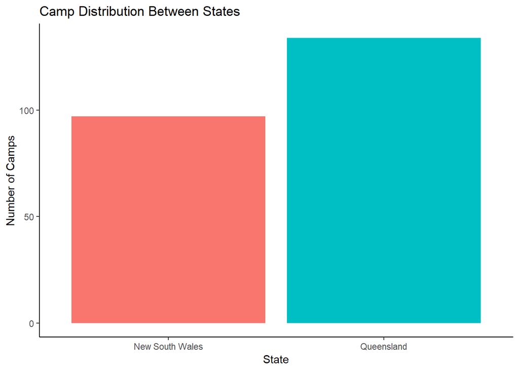

```r
###################################################################################################
# Set Working Environment, Import Dependencies, and Load Data
###################################################################################################

#setwd("C:/Users/Nathan/Desktop/Project 1/Code")

library(ggplot2)
source("helpers.R")

# load camp dataframe
CAMP <- read.csv("../Data/Final/Camp/Camp_Final.csv")

###################################################################################################
# Plot for Camp Distribution Between States
###################################################################################################

p1 <- ggplot(CAMP, aes(x=State, fill=State)) +
  theme_classic() +
  geom_bar(stat="count") +
  ggtitle("Camp Distribution Between States") +
  xlab("State") +
  ylab("Number of Camps") +
  scale_fill_discrete(guide=F)
p1
```

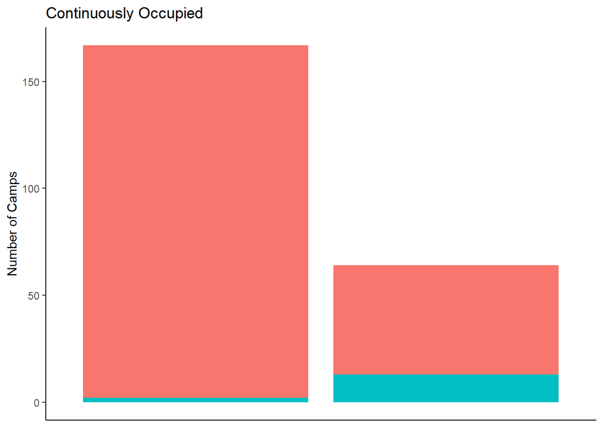

```r
#dev.copy(png, "../Figures/Camp/Camp Distribution Between States.png")
#dev.off()

###################################################################################################
# Plot for Continuously Occupied
###################################################################################################

p1 <- ggplot(CAMP, aes(x=as.factor(Cont), fill=as.factor(Event))) +
  theme_classic() +
  theme(axis.title.x=element_blank(), axis.ticks.x=element_blank(), axis.text.x=element_blank()) +
  geom_bar(stat="count") +
  ggtitle("Continuously Occupied") +
  xlab("") +
  ylab("Number of Camps") +
  scale_fill_discrete(guide=F)
p1
```

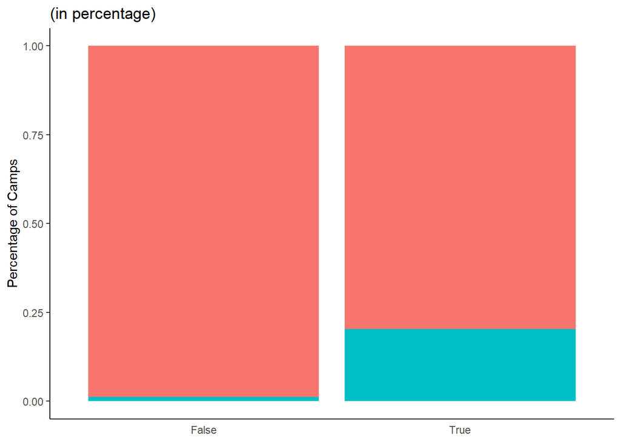

```r
p2 <- ggplot(CAMP, aes(x=as.factor(Cont), fill=as.factor(Event))) +
  theme_classic() +
  theme(axis.title.x=element_blank(), axis.ticks.x=element_blank()) +
  geom_bar(stat="count", position="fill") +
  ggtitle("(in percentage)") +
  xlab("") +
  ylab("Percentage of Camps") +
  scale_x_discrete(labels=c("False", "True")) +
  scale_fill_discrete(guide=F)
p2
```

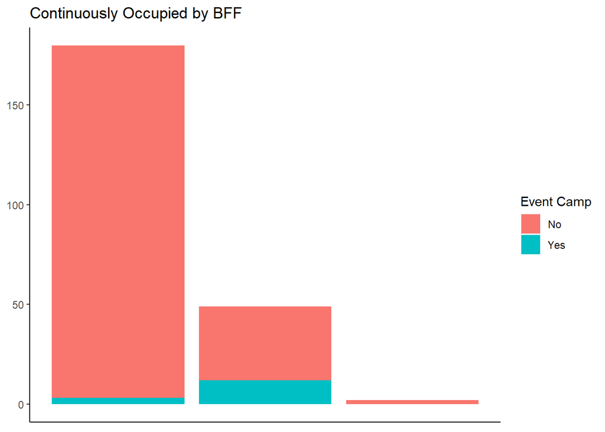

```r
p3 <- ggplot(CAMP, aes(x=as.factor(Cont_Bff), fill=as.factor(Event))) +
  theme_classic() +
  theme(axis.title.x=element_blank(), axis.ticks.x=element_blank(), axis.text.x=element_blank(),
        axis.title.y=element_blank()) +
  geom_bar(stat="count") +
  ggtitle("Continuously Occupied by BFF") +
  xlab("") +
  scale_fill_discrete(aes(title="Event Camp"), labels=c("No", "Yes"))
p3
```

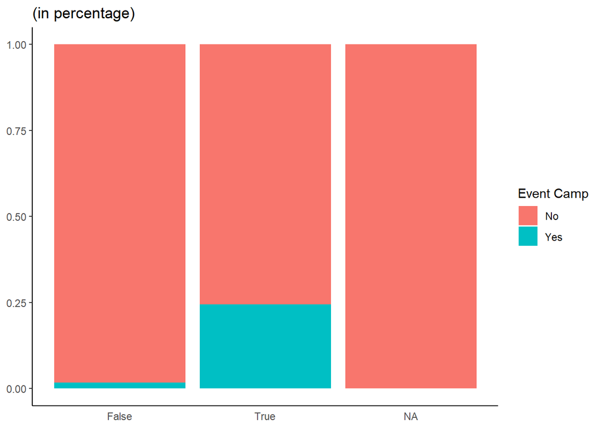

```r
p4 <- ggplot(CAMP, aes(x=as.factor(Cont_Bff), fill=as.factor(Event))) +
  theme_classic() +
  theme(axis.title.x=element_blank(), axis.ticks.x=element_blank(), axis.title.y=element_blank()) +
  geom_bar(stat="count", position="fill") +
  ggtitle("(in percentage)") +
  xlab("") +
  scale_x_discrete(labels=c("False", "True")) +
  scale_fill_discrete(aes(title="Event Camp"), labels=c("No", "Yes"))
p4
```

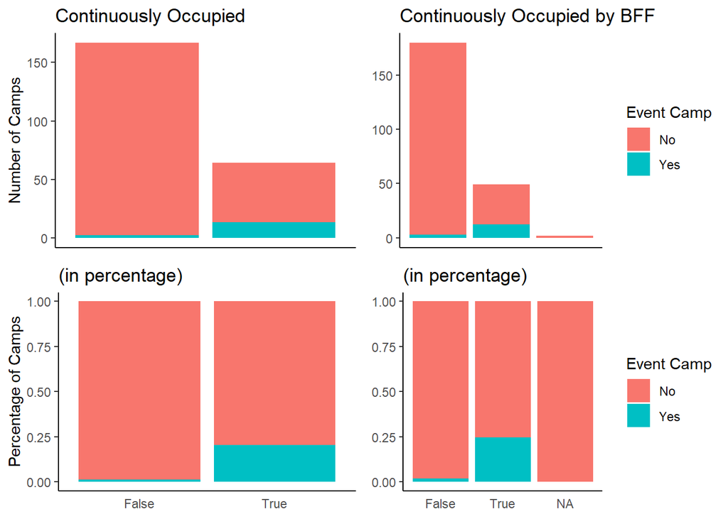

```r
multiplot(p1, p2, p3, p4, cols=2)
```

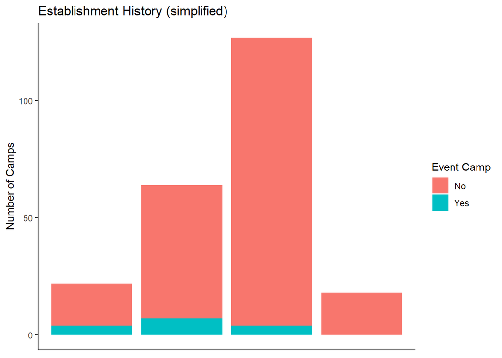

```r
#dev.copy(png, "../Figures/Camp/Continuously Occupied.png")
#dev.off()

###################################################################################################
# Plot for Establishment History (simplified)
###################################################################################################

p1 <- ggplot(CAMP, aes(x=Hist_Simp, fill=as.factor(Event))) +
  theme_classic() +
  theme(axis.title.x=element_blank(), axis.ticks.x=element_blank(), axis.text.x=element_blank()) +
  geom_bar(stat="count") +
  ggtitle("Establishment History (simplified)") +
  xlab("") +
  ylab("Number of Camps") +
  scale_fill_discrete(aes(title="Event Camp"), labels=c("No", "Yes"))
p1
```

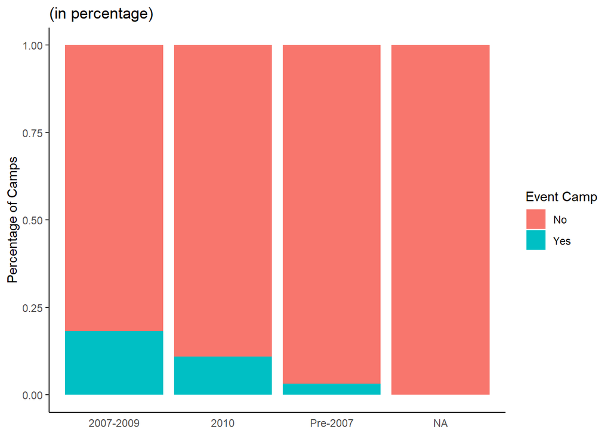

```r
p2 <- ggplot(CAMP, aes(x=Hist_Simp, fill=as.factor(Event))) +
  theme_classic() +
  theme(axis.title.x=element_blank(), axis.ticks.x=element_blank()) +
  geom_bar(stat="count", position="fill") +
  ggtitle("(in percentage)") +
  xlab("") +
  ylab("Percentage of Camps") +
  scale_fill_discrete(aes(title="Event Camp"), labels=c("No", "Yes"))
p2
```

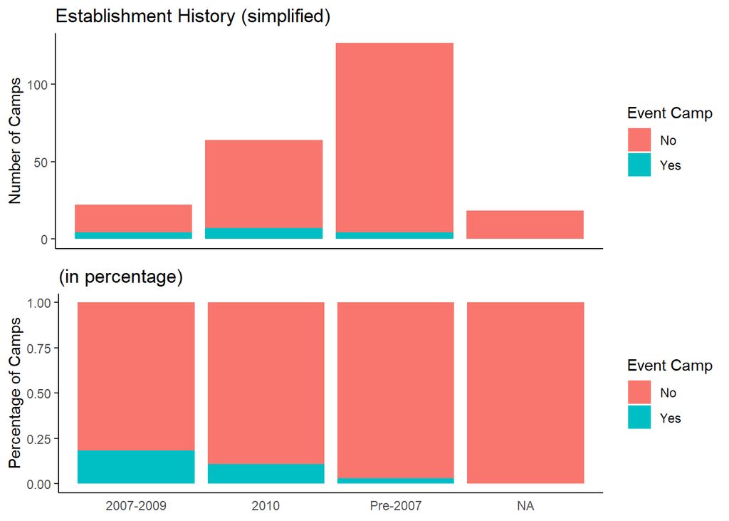

```r
multiplot(p1, p2, cols=1)
```

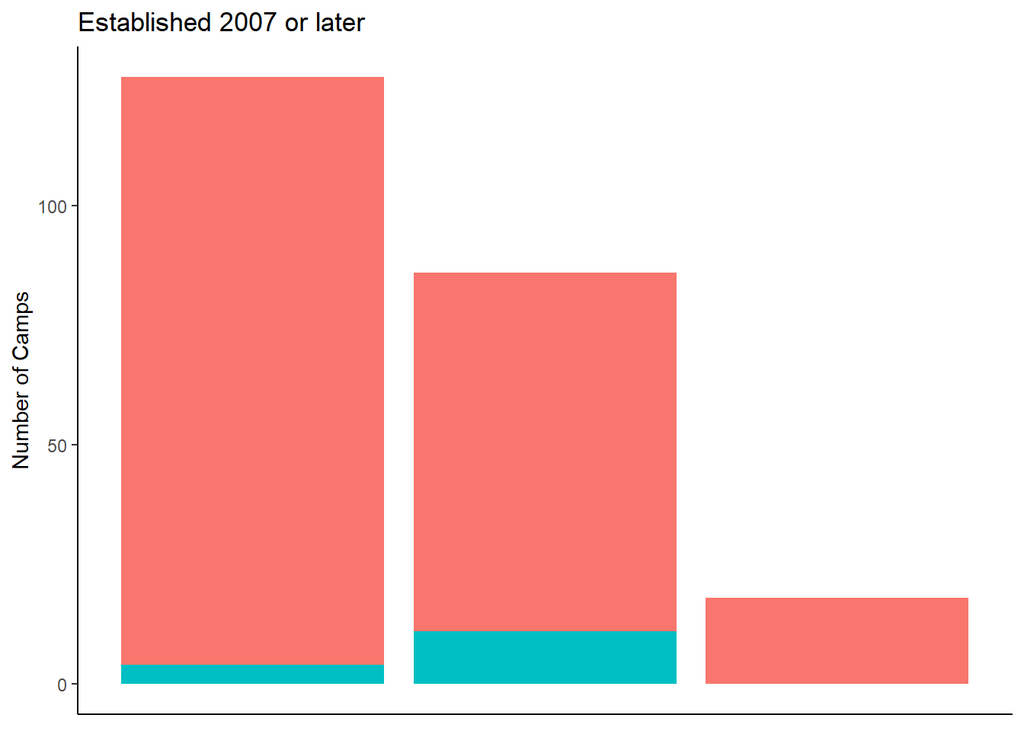

```r
#dev.copy(png, "../Figures/Camp/Establishment History (simplified).png")
#dev.off()

###################################################################################################
# Plot for Established 2007-or_later and 2010-_or_later
###################################################################################################

p1 <- ggplot(CAMP, aes(x=as.factor(Post_07), fill=as.factor(Event))) +
  theme_classic() +
  theme(axis.title.x=element_blank(), axis.ticks.x=element_blank(), axis.text.x=element_blank()) +
  geom_bar(stat="count") +
  ggtitle("Established 2007 or later") +
  xlab("") +
  ylab("Number of Camps") +
  scale_fill_discrete(guide=F)
p1
```

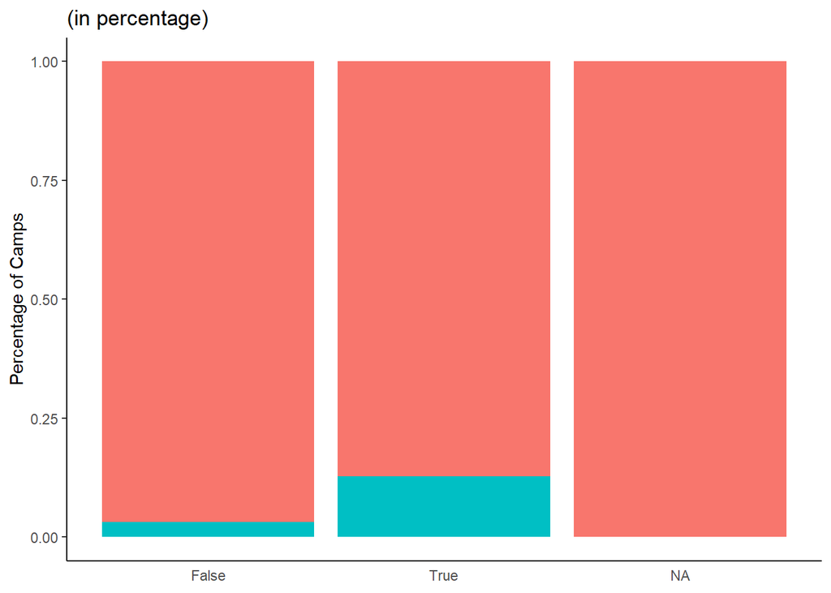

```r
p2 <- ggplot(CAMP, aes(x=as.factor(Post_07), fill=as.factor(Event))) +
  theme_classic() +
  theme(axis.title.x=element_blank(), axis.ticks.x=element_blank()) +
  geom_bar(stat="count", position="fill") +
  ggtitle("(in percentage)") +
  xlab("") +
  ylab("Percentage of Camps") +
  scale_x_discrete(labels=c("False", "True")) +
  scale_fill_discrete(guide=F)
p2
```

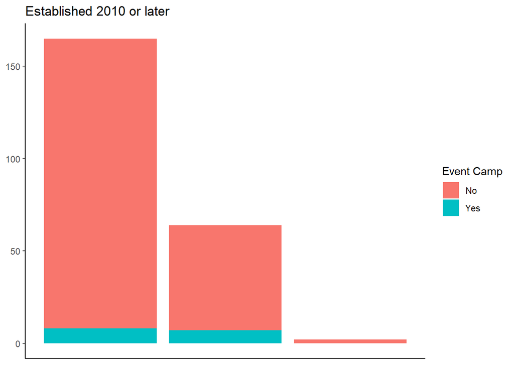

```r
p3 <- ggplot(CAMP, aes(x=as.factor(Post_10), fill=as.factor(Event))) +
  theme_classic() +
  theme(axis.title.x=element_blank(), axis.ticks.x=element_blank(), axis.text.x=element_blank(),
        axis.title.y=element_blank()) +
  geom_bar(stat="count") +
  ggtitle("Established 2010 or later") +
  xlab("") +
  ylab("Number of Camps") +
  scale_x_discrete(labels=c("False", "True")) +
  scale_fill_discrete(aes(title="Event Camp"), labels=c("No", "Yes"))
p3
```

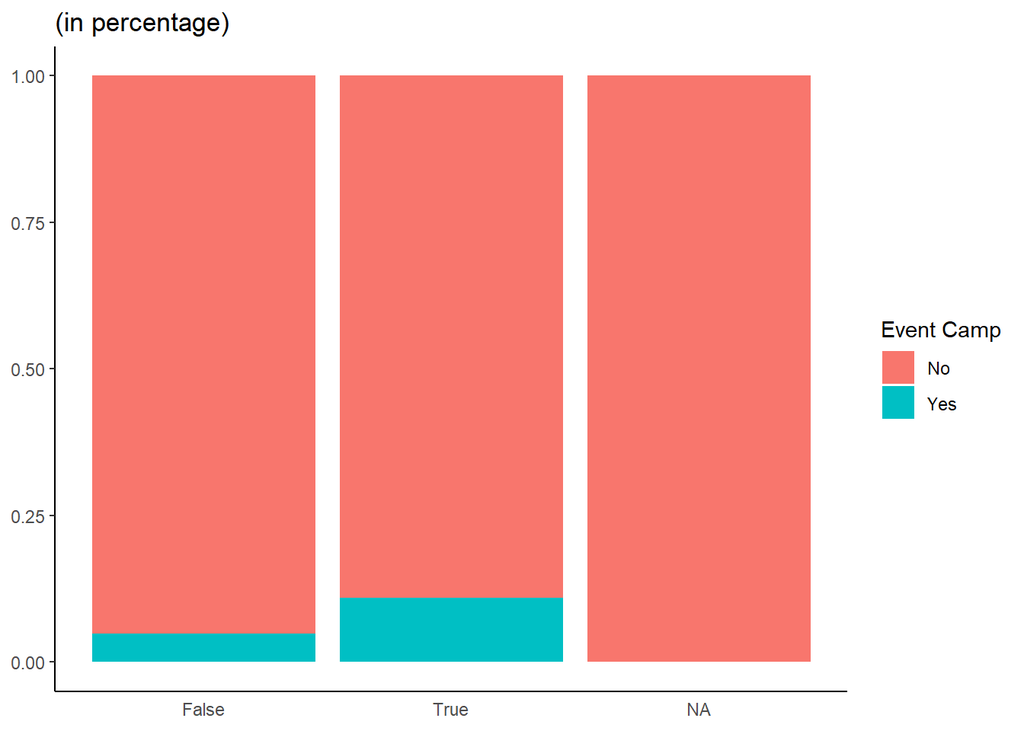

```r
p4 <- ggplot(CAMP, aes(x=as.factor(Post_10), fill=as.factor(Event))) +
  theme_classic() +
  theme(axis.title.x=element_blank(), axis.ticks.x=element_blank(), axis.title.y=element_blank()) +
  geom_bar(stat="count", position="fill") +
  ggtitle("(in percentage)") +
  xlab("") +
  ylab("Percentage of Camps") +
  scale_x_discrete(labels=c("False", "True")) +
  scale_fill_discrete(aes(title="Event Camp"), labels=c("No", "Yes"))
p4
```

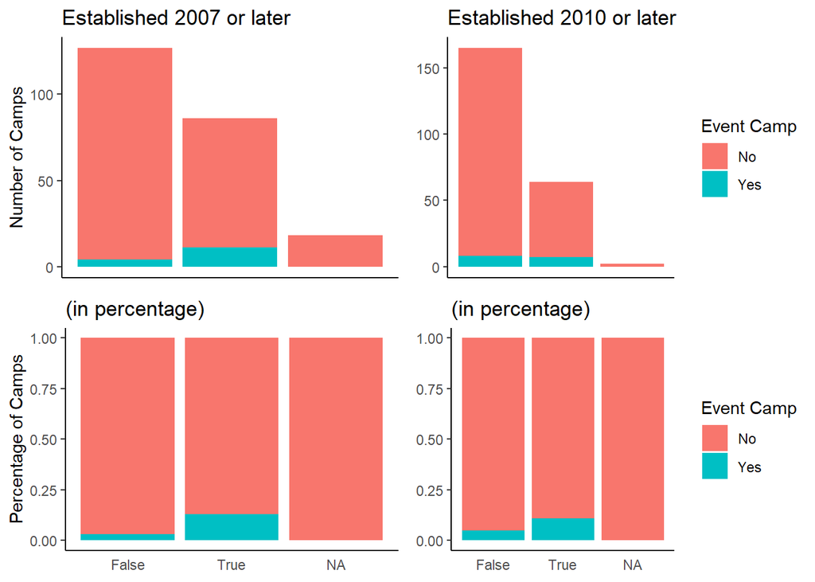

```r
multiplot(p1, p2, p3, p4, cols=2)
```

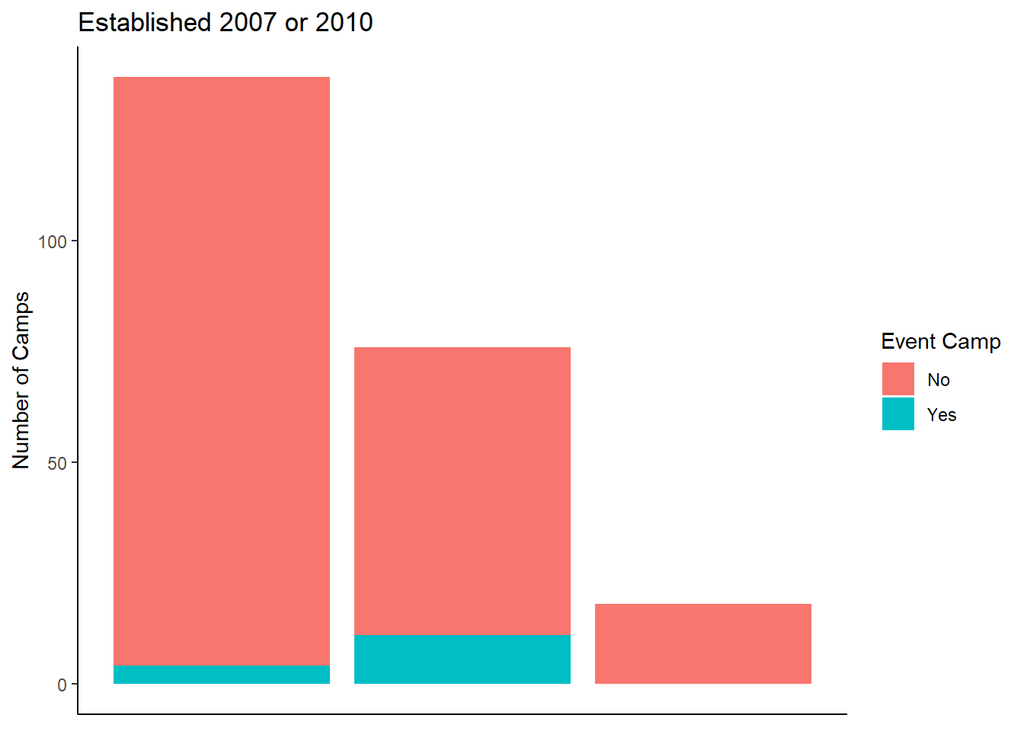

```r
#dev.copy(png, "../Figures/Camp/Established 2007-or_later and 2010-_or_later.png")
#dev.off()

###################################################################################################
# Plot for Established 2007_2010
###################################################################################################

p1 <- ggplot(CAMP, aes(x=as.factor(Short_07_10), fill=as.factor(Event))) +
  theme_classic() +
  theme(axis.title.x=element_blank(), axis.ticks.x=element_blank(), axis.text.x=element_blank()) +
  geom_bar(stat="count") +
  ggtitle("Established 2007 or 2010") +
  xlab("") +
  ylab("Number of Camps") +
  scale_x_discrete(labels=c("False", "True")) +
  scale_fill_discrete(aes(title="Event Camp"), labels=c("No", "Yes"))
p1
```

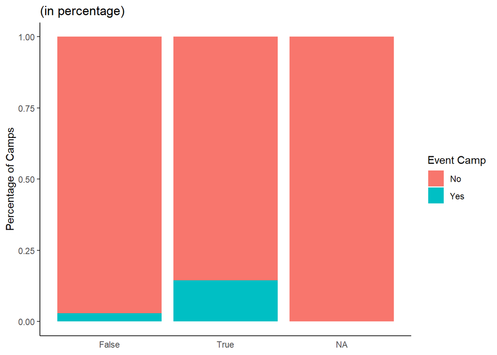

```r
p2 <- ggplot(CAMP, aes(x=as.factor(Short_07_10), fill=as.factor(Event))) +
  theme_classic() +
  theme(axis.title.x=element_blank(), axis.ticks.x=element_blank()) +
  geom_bar(stat="count", position="fill") +
  ggtitle("(in percentage)") +
  xlab("") +
  ylab("Percentage of Camps") +
  scale_x_discrete(labels=c("False", "True")) +
  scale_fill_discrete(aes(title="Event Camp"), labels=c("No", "Yes"))
p2
```

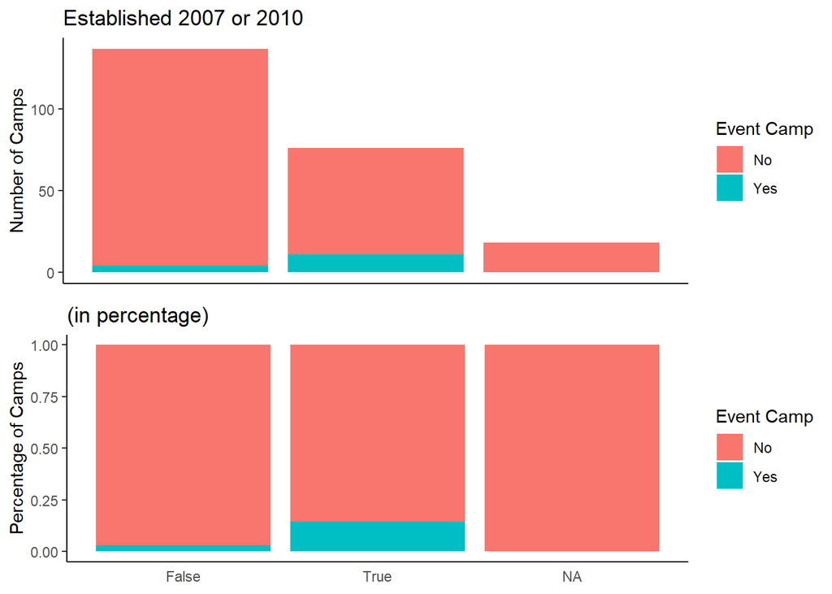

```r
multiplot(p1, p2, cols=1)
```

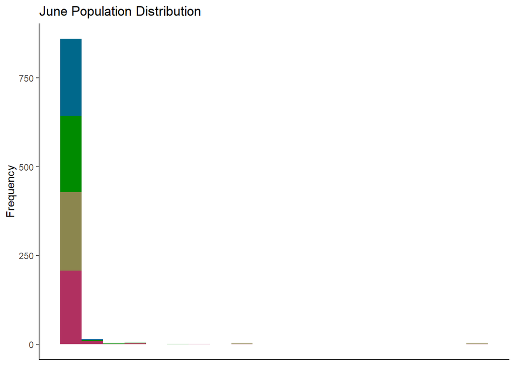

```r
#dev.copy(png, "../Figures/Camp/Established 2007_2010.png")
#dev.off()

###################################################################################################
# Plot for Monthly Population Distribution
###################################################################################################

# purpose: create a transformed dataframe containing species population counts from wide-form to
  # long-form for plotting
# input: BFF population count, GHFF population count, LRFF population count, total population count,
  # value for the max value subset, Boolean for whether or not zero-counts should be included
# output: transformed dataframe of species population counts in long-form
fitCensusData <- function(bff, ghff, lrff, tot, tail=F, zero=T) {
  output <- data.frame(species=rep("BFF", length(bff)), count=bff)
  output <- rbind(output, data.frame(species=rep("GHFF", length(ghff)), count=ghff))
  output <- rbind(output, data.frame(species=rep("LRFF", length(lrff)), count=lrff))
  output <- rbind(output, data.frame(species=rep("Total", length(tot)), count=tot))

  if (!tail && !zero) {
    output <- subset(output, count != 0)
  } else if (tail && zero) {
    output <- subset(output, count <= tail)
  } else if (tail && !zero) {
    output <- subset(output, count <= tail)
    output <- subset(output, count != 0)
  }

  return(output)
}

df <- fitCensusData(CAMP$Bff6, CAMP$GHff6, CAMP$LRff6, CAMP$Tot6)

p1 <- ggplot(df, aes(count, fill=species)) +
  theme_classic() +
  theme(axis.title.x=element_blank(), axis.ticks.x=element_blank(), axis.text.x=element_blank()) +
  geom_histogram(show.legend=F, bins=20) +
  ggtitle("June Population Distribution") +
  xlab("Population Count") +
  ylab("Frequency") +
  scale_fill_manual("Species", limits=c("BFF", "GHFF", "LRFF", "Total"),
                    values=c("deepskyblue4", "green4", "khaki4", "maroon"))
p1
```

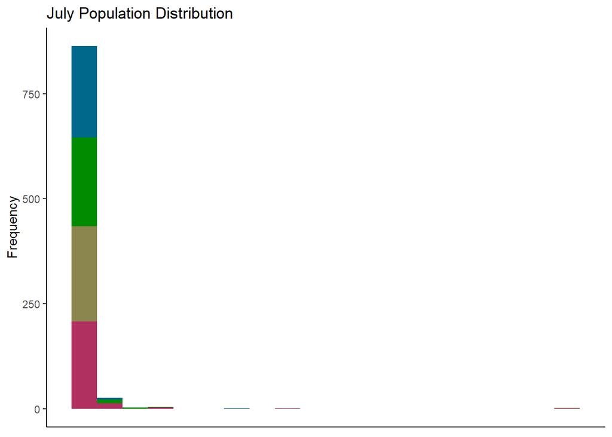

```r
df <- fitCensusData(CAMP$Bff7, CAMP$GHff7, CAMP$LRff7, CAMP$Tot7)

p2 <- ggplot(df, aes(count, fill=species)) +
  theme_classic() +
  theme(axis.title.x=element_blank(), axis.ticks.x=element_blank(), axis.text.x=element_blank()) +
  geom_histogram(show.legend=F, bins=20) +
  ggtitle("July Population Distribution") +
  xlab("Population Count") +
  ylab("Frequency") +
  scale_fill_manual("Species", limits=c("BFF", "GHFF", "LRFF", "Total"),
                    values=c("deepskyblue4", "green4", "khaki4", "maroon"))
p2
```

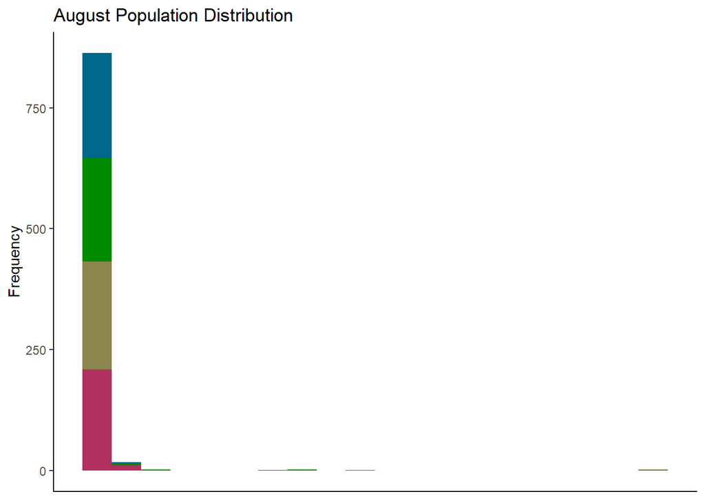

```r
df <- fitCensusData(CAMP$Bff8, CAMP$GHff8, CAMP$LRff8, CAMP$Tot8)

p3 <- ggplot(df, aes(count, fill=species)) +
  theme_classic() +
  theme(axis.title.x=element_blank(), axis.ticks.x=element_blank(), axis.text.x=element_blank()) +
  geom_histogram(show.legend=F, bins=20) +
  ggtitle("August Population Distribution") +
  xlab("Population Count") +
  ylab("Frequency") +
  scale_fill_manual("Species", limits=c("BFF", "GHFF", "LRFF", "Total"),
                    values=c("deepskyblue4", "green4", "khaki4", "maroon"))
p3
```

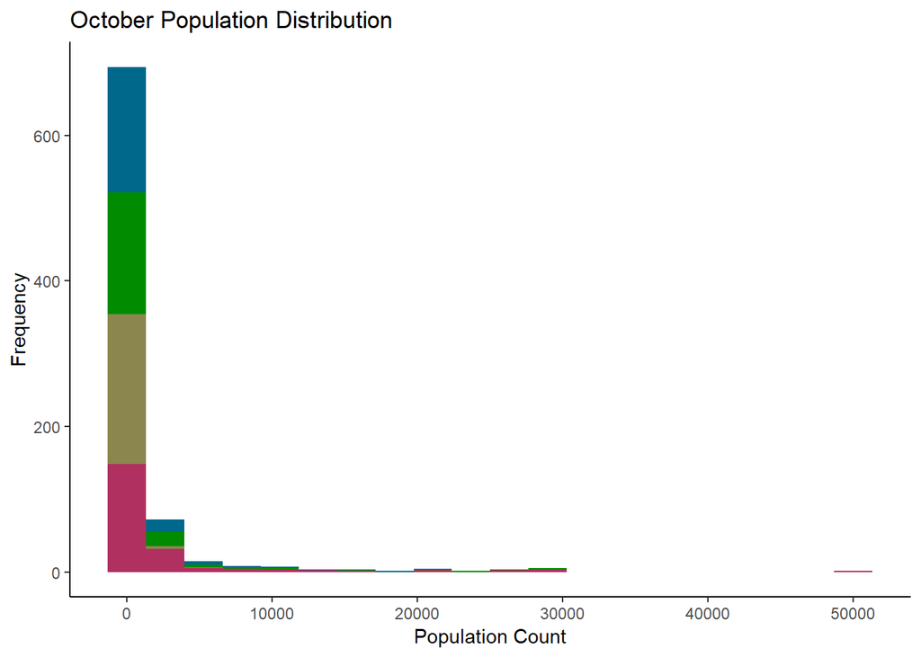

```r
df <- fitCensusData(CAMP$Bff10, CAMP$GHff10, CAMP$LRff10, CAMP$Tot10)

p4 <- ggplot(df, aes(count, fill=species)) +
  theme_classic() +
  geom_histogram(show.legend=F, bins=20) +
  ggtitle("October Population Distribution") +
  xlab("Population Count") +
  ylab("Frequency") +
  scale_fill_manual("Species", limits=c("BFF", "GHFF", "LRFF", "Total"),
                    values=c("deepskyblue4", "green4", "khaki4", "maroon"))
p4
```

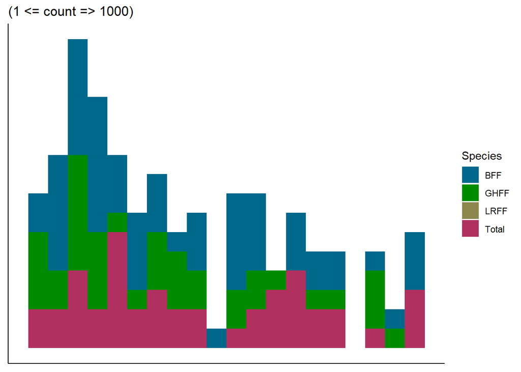

```r
df <- fitCensusData(CAMP$Bff6, CAMP$GHff6, CAMP$LRff6, CAMP$Tot6, tail=1000, zero=F)

p5 <- ggplot(df, aes(count, fill=species)) +
  theme_classic() +
  theme(axis.title.x=element_blank(), axis.ticks.x=element_blank(), axis.text.x=element_blank(),
        axis.title.y=element_blank(), axis.ticks.y=element_blank(), axis.text.y=element_blank()) +
  geom_histogram(bins=20) +
  ggtitle("(1 <= count => 1000)") +
  xlab("Population Count") +
  ylab("Frequency") +
  scale_fill_manual("Species", limits=c("BFF", "GHFF", "LRFF", "Total"),
                    values=c("deepskyblue4", "green4", "khaki4", "maroon"))
p5
```

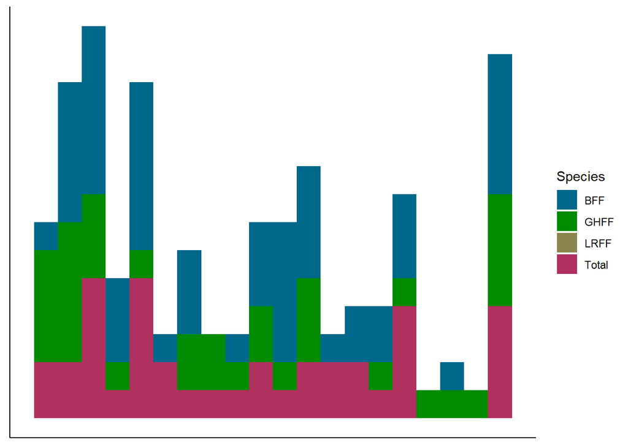

```r
df <- fitCensusData(CAMP$Bff7, CAMP$GHff7, CAMP$LRff7, CAMP$Tot7, tail=1000, zero=F)

p6 <- ggplot(df, aes(count, fill=species)) +
  theme_classic() +
  theme(axis.title.x=element_blank(), axis.ticks.x=element_blank(), axis.text.x=element_blank(),
        axis.title.y=element_blank(), axis.ticks.y=element_blank(), axis.text.y=element_blank()) +
  geom_histogram(bins=20) +
  xlab("Population Count") +
  ylab("Frequency") +
  scale_fill_manual("Species", limits=c("BFF", "GHFF", "LRFF", "Total"),
                    values=c("deepskyblue4", "green4", "khaki4", "maroon"))
p6
```

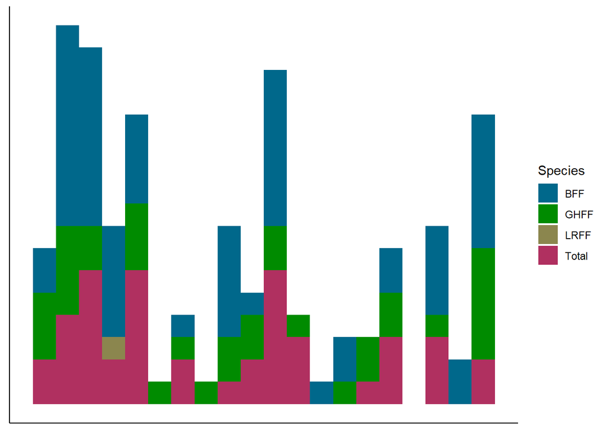

```r
df <- fitCensusData(CAMP$Bff8, CAMP$GHff8, CAMP$LRff8, CAMP$Tot8, tail=1000, zero=F)

p7 <- ggplot(df, aes(count, fill=species)) +
  theme_classic() +
  theme(axis.title.x=element_blank(), axis.ticks.x=element_blank(), axis.text.x=element_blank(),
        axis.title.y=element_blank(), axis.ticks.y=element_blank(), axis.text.y=element_blank()) +
  geom_histogram(bins=20) +
  xlab("Population Count") +
  ylab("Frequency") +
  scale_fill_manual("Species", limits=c("BFF", "GHFF", "LRFF", "Total"),
                    values=c("deepskyblue4", "green4", "khaki4", "maroon"))
p7
```

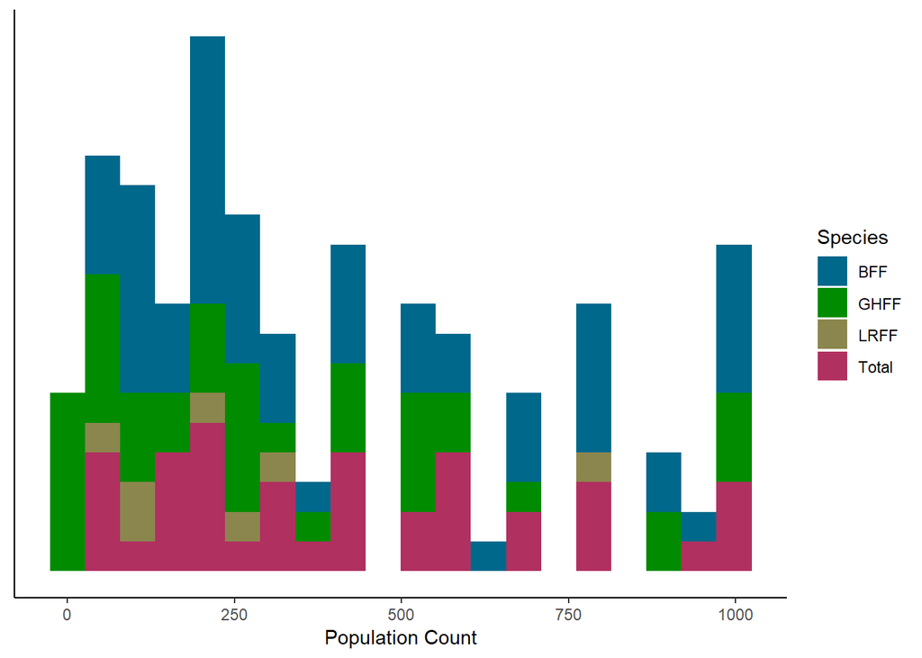

```r
df <- fitCensusData(CAMP$Bff10, CAMP$GHff10, CAMP$LRff10, CAMP$Tot10, tail=1000, zero=F)

p8 <- ggplot(df, aes(count, fill=species)) +
  theme_classic() +
  theme(axis.title.y=element_blank(), axis.ticks.y=element_blank(), axis.text.y=element_blank()) +
  geom_histogram(bins=20) +
  xlab("Population Count") +
  ylab("Frequency") +
  scale_fill_manual("Species", limits=c("BFF", "GHFF", "LRFF", "Total"),
                    values=c("deepskyblue4", "green4", "khaki4", "maroon"))
p8
```

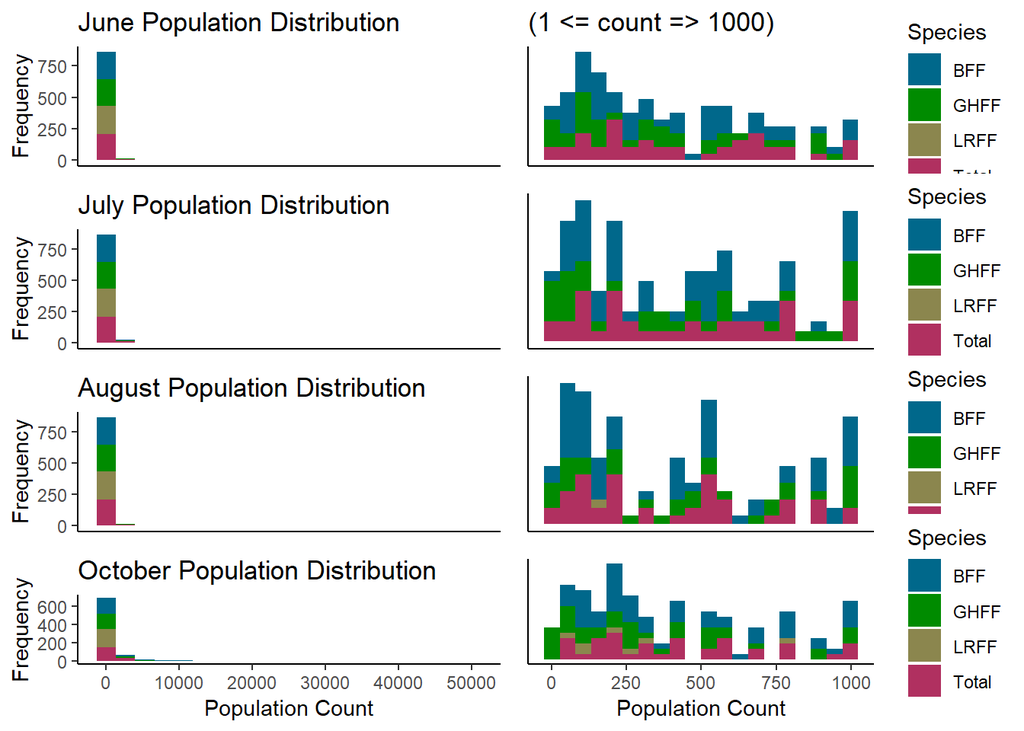

```r
multiplot(p1, p2, p3, p4, p5, p6, p7, p8, cols=2)
```

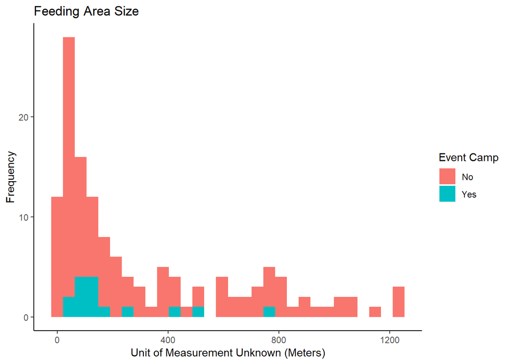

```r
#dev.copy(png, "../Figures/Camp/Monthly Population Distribution.png")
#dev.off()

###################################################################################################
# Plot for Landuse
###################################################################################################

p1 <- ggplot(CAMP, aes(Fa_Size, fill=as.factor(Event))) +
  theme_classic() +
  geom_histogram(bins=30) +
  ggtitle("Feeding Area Size") +
  xlab("Unit of Measurement Unknown (Meters)") +
  ylab("Frequency") +
  scale_fill_discrete(aes(title="Event Camp"), labels=c("No", "Yes"))
p1
```

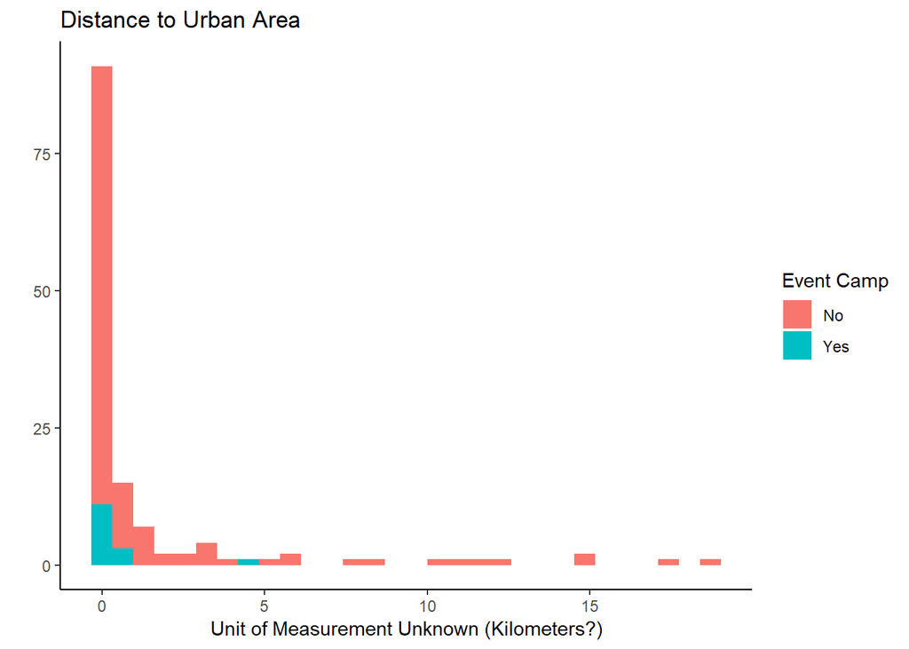

```r
p2 <- ggplot(CAMP, aes(Dist_Urb, fill=as.factor(Event))) +
  theme_classic() +
  geom_histogram(bins=30) +
  ggtitle("Distance to Urban Area") +
  xlab("Unit of Measurement Unknown (Kilometers?)") +
  ylab("") +
  scale_fill_discrete(aes(title="Event Camp"), labels=c("No", "Yes"))
p2
```

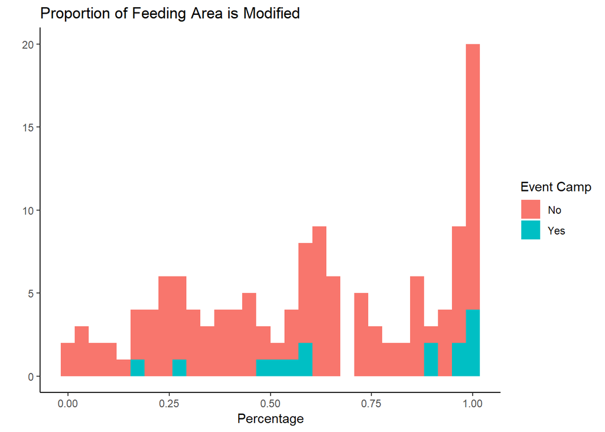

```r
p3 <- ggplot(CAMP, aes(Prop_Mod, fill=as.factor(Event))) +
  theme_classic() +
  geom_histogram(bins=30) +
  ggtitle("Proportion of Feeding Area is Modified") +
  xlab("Percentage") +
  ylab("") +
  scale_fill_discrete(aes(title="Event Camp"), labels=c("No", "Yes"))
p3
```

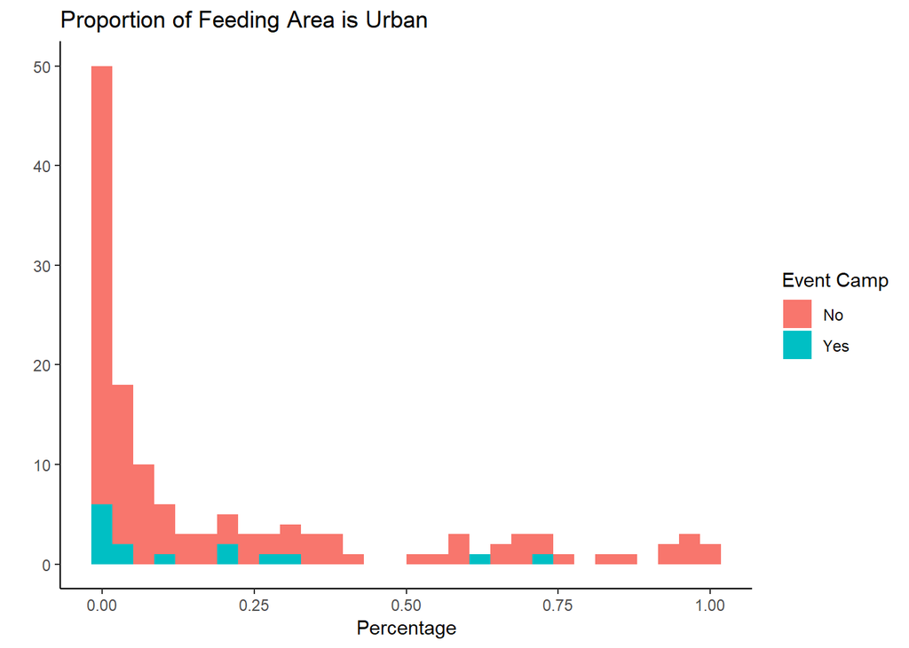

```r
p4 <- ggplot(CAMP, aes(Prop_Urb, fill=as.factor(Event))) +
  theme_classic() +
  geom_histogram(bins=30) +
  ggtitle("Proportion of Feeding Area is Urban") +
  xlab("Percentage") +
  ylab("") +
  scale_fill_discrete(aes(title="Event Camp"), labels=c("No", "Yes"))
p4
```

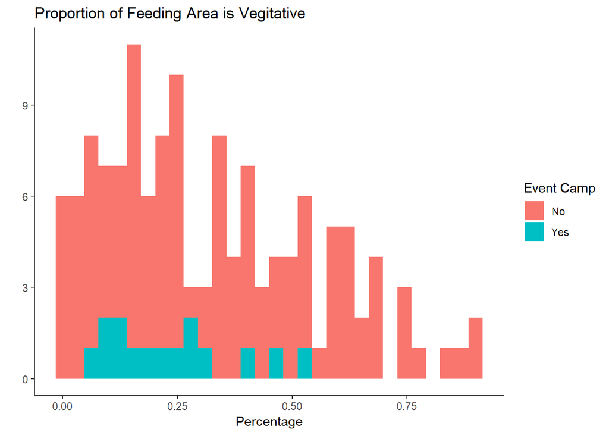

```r
p5 <- ggplot(CAMP, aes(Prop_Veg, fill=as.factor(Event))) +
  theme_classic() +
  geom_histogram(bins=30) +
  ggtitle("Proportion of Feeding Area is Vegitative") +
  xlab("Percentage") +
  ylab("") +
  scale_fill_discrete(aes(title="Event Camp"), labels=c("No", "Yes"))
p5
```

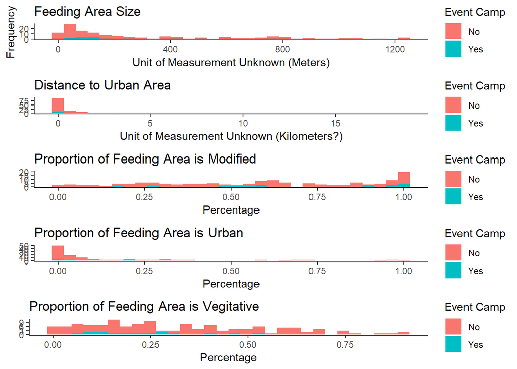

```r
multiplot(p1, p2, p3, p4, p5, cols=1)
```

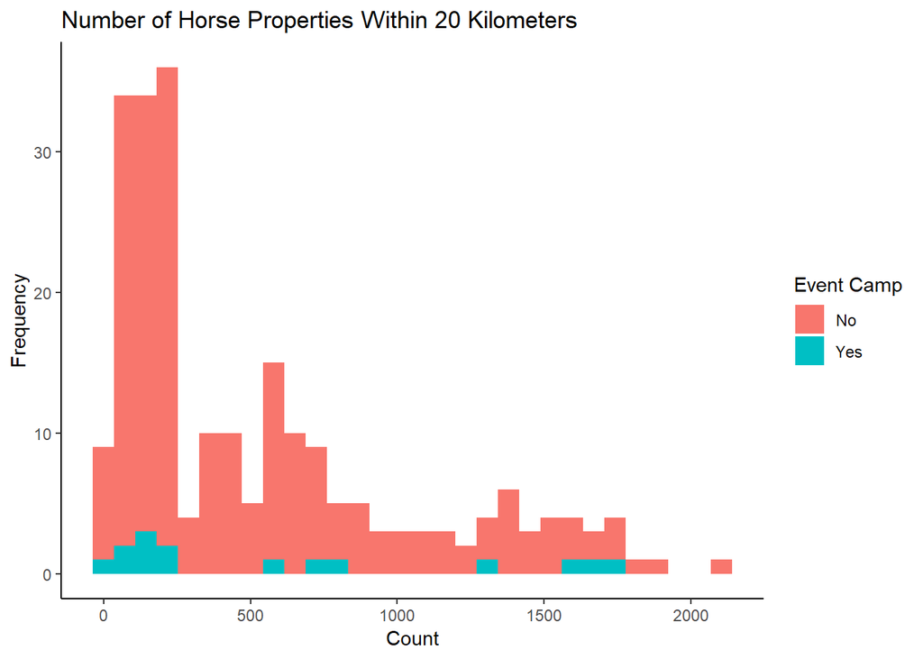

```r
#dev.copy(png, "../Figures/Camp/Landuse.png")
#dev.off()

###################################################################################################
# Plot for Horse Properties
###################################################################################################

p1 <- ggplot(CAMP, aes(Prop_Num_20km, fill=as.factor(Event))) +
  theme_classic() +
  geom_histogram(bins=30) +
  ggtitle("Number of Horse Properties Within 20 Kilometers") +
  xlab("Count") +
  ylab("Frequency") +
  scale_fill_discrete(aes(title="Event Camp"), labels=c("No", "Yes"))
p1
```

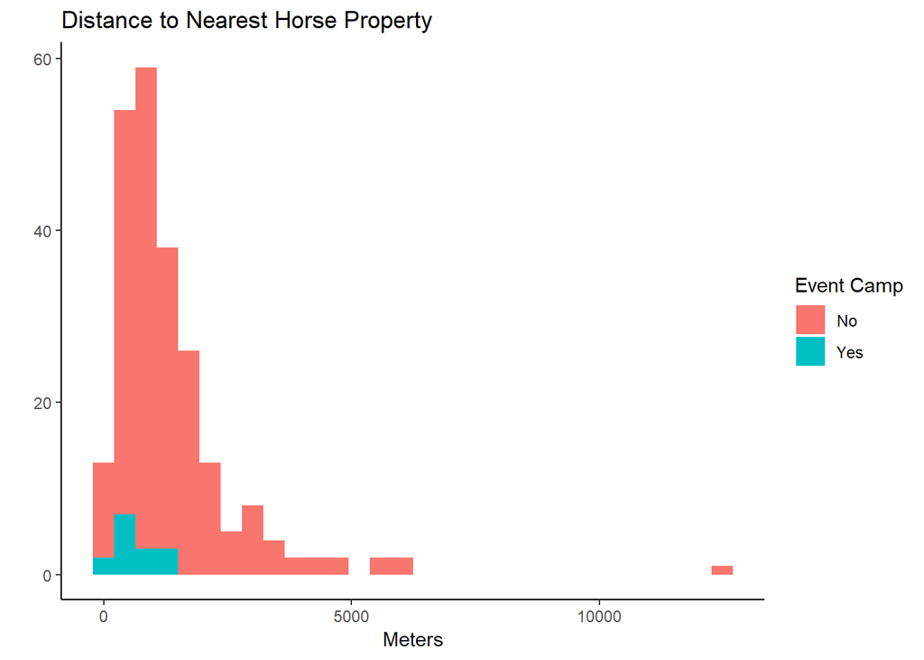

```r
p2 <- ggplot(CAMP, aes(Prop_Near_Dist, fill=as.factor(Event))) +
  theme_classic() +
  geom_histogram(bins=30) +
  ggtitle("Distance to Nearest Horse Property") +
  xlab("Meters") +
  ylab("") +
  scale_fill_discrete(aes(title="Event Camp"), labels=c("No", "Yes"))
p2
```

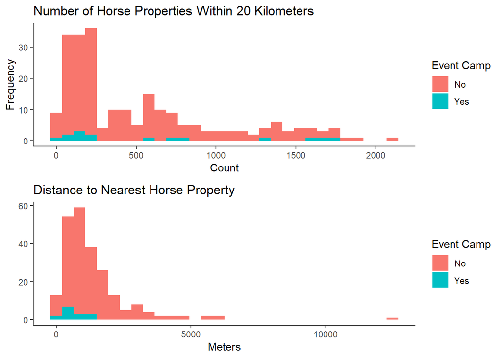

```r
multiplot(p1, p2, cols=1)
```

```r
#dev.copy(png, "../Figures/Camp/Horse Properties.png")
#dev.off()
```

# GLM Univariate Modeling

## The purpose of this section is run univariate GLM models on the camp data related to the research question and hypothesis

- 1 = Event Camp : camp was the closest occupied camp to a spillover event
- 0 = Not an Event Camp
- Null => No statistical difference between the characteristics of Event Camps and Non-Event Camps, therefore due to chance or covariates beyond the scope of the study

```r
###################################################################################################
# Set Working Environment, Import Dependencies, and Load Data
###################################################################################################

#setwd("C:/Users/Nathan/Desktop/Project 1/Code")

library(stargazer)
library(MASS)
```

```r
# load camp dataset
df <- read.csv("../Data/Final/Camp/Camp_Final.csv")

# store the covariates to be modelled
covars <- c("Cont", "Cont_Bff", "Hist_Simp", "Post_07", "Post_10", "Short_07_10", "Short_Any",
            "Fa_Size", "Dist_Urb", "Prop_Mod", "Prop_Urb", "Prop_Veg", "Prop_In_20km",
            "Prop_Near_Dist")

# ititialize the HTML string for the model results
starTable <- ""

# purpose: runs univariate model of passed covariate and builds HTML table of results
# input: the current HTML string of model results, covariate to be modelled, title of table results,
  # label for dependant variable, label for covariate
# output: HTML string of model results
buildStarTable <- function(starTable, covar, title, dep.var.labels, covariate.labels) {
  # ititialize return object
  output <- ""

  # run model
  model <- glm(as.formula(paste("Event ~", covar, sep=" ")), family="binomial", df)

  # build HTML string of results
  gaze <- stargazer(model, type="html", ci=T, title=title, dep.var.labels=dep.var.labels,
                    covariate.labels=covariate.labels, apply.coef=exp)
  starTable <- paste(starTable, gaze, sep="")

  for (i in 1:length(gaze)) {
    output <- paste(output, gaze[i], sep="")
  }

  # append spacing for readability
  output <- paste(output, '<div style="height: 50px;"></div>')

  # return HTML table of model results
  return(output)
}

###################################################################################################
# Model and Table for Cont
###################################################################################################

covar <- "Cont"
title <- "Continuously Occupied"
dep.var.labels = c("0 = false, 1 = true")
covariate.labels <- c("Continuously Occupied")
starTable <- paste(starTable,
                   buildStarTable(starTable, covar, title, dep.var.labels, covariate.labels),
                   sep="")
```

```
##
## <table style="text-align:center"><caption><strong>Continuously Occupied</strong></caption>
## <tr><td colspan="2" style="border-bottom: 1px solid black"></td></tr><tr><td style="text-align:left"></td><td><em>Dependent variable:</em></td></tr>
## <tr><td></td><td colspan="1" style="border-bottom: 1px solid black"></td></tr>
## <tr><td style="text-align:left"></td><td>0 = false, 1 = true</td></tr>
## <tr><td colspan="2" style="border-bottom: 1px solid black"></td></tr><tr><td style="text-align:left">Continuously Occupied</td><td>21.029<sup>***</sup></td></tr>
## <tr><td style="text-align:left"></td><td>(19.508, 22.551)</td></tr>
## <tr><td style="text-align:left"></td><td></td></tr>
## <tr><td style="text-align:left">Constant</td><td>0.012</td></tr>
## <tr><td style="text-align:left"></td><td>(-1.382, 1.406)</td></tr>
## <tr><td style="text-align:left"></td><td></td></tr>
## <tr><td colspan="2" style="border-bottom: 1px solid black"></td></tr><tr><td style="text-align:left">Observations</td><td>231</td></tr>
## <tr><td style="text-align:left">Log Likelihood</td><td>-43.139</td></tr>
## <tr><td style="text-align:left">Akaike Inf. Crit.</td><td>90.277</td></tr>
## <tr><td colspan="2" style="border-bottom: 1px solid black"></td></tr><tr><td style="text-align:left"><em>Note:</em></td><td style="text-align:right"><sup>*</sup>p<0.1; <sup>**</sup>p<0.05; <sup>***</sup>p<0.01</td></tr>
## </table>
```

```r
###################################################################################################
# Model and Table for Cont_Bff
###################################################################################################

covar <- "Cont_Bff"
title <- "Continuously Occupied by BFF"
dep.var.labels = c("0 = false, 1 = true")
covariate.labels <- c("Continuously Occupied by BFF")
starTable <- paste(starTable,
                   buildStarTable(starTable, covar, title, dep.var.labels, covariate.labels),
                   sep="")
```

```
##
## <table style="text-align:center"><caption><strong>Continuously Occupied by BFF</strong></caption>
## <tr><td colspan="2" style="border-bottom: 1px solid black"></td></tr><tr><td style="text-align:left"></td><td><em>Dependent variable:</em></td></tr>
## <tr><td></td><td colspan="1" style="border-bottom: 1px solid black"></td></tr>
## <tr><td style="text-align:left"></td><td>0 = false, 1 = true</td></tr>
## <tr><td colspan="2" style="border-bottom: 1px solid black"></td></tr><tr><td style="text-align:left">Continuously Occupied by BFF</td><td>19.135<sup>***</sup></td></tr>
## <tr><td style="text-align:left"></td><td>(17.822, 20.449)</td></tr>
## <tr><td style="text-align:left"></td><td></td></tr>
## <tr><td style="text-align:left">Constant</td><td>0.017</td></tr>
## <tr><td style="text-align:left"></td><td>(-1.124, 1.158)</td></tr>
## <tr><td style="text-align:left"></td><td></td></tr>
## <tr><td colspan="2" style="border-bottom: 1px solid black"></td></tr><tr><td style="text-align:left">Observations</td><td>229</td></tr>
## <tr><td style="text-align:left">Log Likelihood</td><td>-42.534</td></tr>
## <tr><td style="text-align:left">Akaike Inf. Crit.</td><td>89.068</td></tr>
## <tr><td colspan="2" style="border-bottom: 1px solid black"></td></tr><tr><td style="text-align:left"><em>Note:</em></td><td style="text-align:right"><sup>*</sup>p<0.1; <sup>**</sup>p<0.05; <sup>***</sup>p<0.01</td></tr>
## </table>
```

```r
###################################################################################################
# Model and Table for Hist_Simp
###################################################################################################

covar <- "Hist_Simp"
title <- "History of Establishment"
dep.var.labels = c("Pre-2007, 2007-2009, 2010")
covariate.labels <- c("History")
starTable <- paste(starTable,
                   buildStarTable(starTable, covar, title, dep.var.labels, covariate.labels),
                   sep="")
```

```
##
## <table style="text-align:center"><caption><strong>History of Establishment</strong></caption>
## <tr><td colspan="2" style="border-bottom: 1px solid black"></td></tr><tr><td style="text-align:left"></td><td><em>Dependent variable:</em></td></tr>
## <tr><td></td><td colspan="1" style="border-bottom: 1px solid black"></td></tr>
## <tr><td style="text-align:left"></td><td>Pre-2007, 2007-2009, 2010</td></tr>
## <tr><td colspan="2" style="border-bottom: 1px solid black"></td></tr><tr><td style="text-align:left">History</td><td>0.553</td></tr>
## <tr><td style="text-align:left"></td><td>(-0.785, 1.891)</td></tr>
## <tr><td style="text-align:left"></td><td></td></tr>
## <tr><td style="text-align:left">Hist_SimpPre-2007</td><td>0.146</td></tr>
## <tr><td style="text-align:left"></td><td>(-1.325, 1.618)</td></tr>
## <tr><td style="text-align:left"></td><td></td></tr>
## <tr><td style="text-align:left">Constant</td><td>0.222</td></tr>
## <tr><td style="text-align:left"></td><td>(-0.861, 1.306)</td></tr>
## <tr><td style="text-align:left"></td><td></td></tr>
## <tr><td colspan="2" style="border-bottom: 1px solid black"></td></tr><tr><td style="text-align:left">Observations</td><td>213</td></tr>
## <tr><td style="text-align:left">Log Likelihood</td><td>-50.292</td></tr>
## <tr><td style="text-align:left">Akaike Inf. Crit.</td><td>106.584</td></tr>
## <tr><td colspan="2" style="border-bottom: 1px solid black"></td></tr><tr><td style="text-align:left"><em>Note:</em></td><td style="text-align:right"><sup>*</sup>p<0.1; <sup>**</sup>p<0.05; <sup>***</sup>p<0.01</td></tr>
## </table>
```

```r
###################################################################################################
# Model and Table for Post_07
###################################################################################################

covar <- "Post_07"
title <- "Established 2007 or Later"
dep.var.labels = c("0 = false, 1 = true")
covariate.labels <- c("Formed 2007 or Later")
starTable <- paste(starTable,
                   buildStarTable(starTable, covar, title, dep.var.labels, covariate.labels),
                   sep="")
```

```
##
## <table style="text-align:center"><caption><strong>Established 2007 or Later</strong></caption>
## <tr><td colspan="2" style="border-bottom: 1px solid black"></td></tr><tr><td style="text-align:left"></td><td><em>Dependent variable:</em></td></tr>
## <tr><td></td><td colspan="1" style="border-bottom: 1px solid black"></td></tr>
## <tr><td style="text-align:left"></td><td>0 = false, 1 = true</td></tr>
## <tr><td colspan="2" style="border-bottom: 1px solid black"></td></tr><tr><td style="text-align:left">Formed 2007 or Later</td><td>4.510<sup>***</sup></td></tr>
## <tr><td style="text-align:left"></td><td>(3.330, 5.690)</td></tr>
## <tr><td style="text-align:left"></td><td></td></tr>
## <tr><td style="text-align:left">Constant</td><td>0.033</td></tr>
## <tr><td style="text-align:left"></td><td>(-0.963, 1.028)</td></tr>
## <tr><td style="text-align:left"></td><td></td></tr>
## <tr><td colspan="2" style="border-bottom: 1px solid black"></td></tr><tr><td style="text-align:left">Observations</td><td>213</td></tr>
## <tr><td style="text-align:left">Log Likelihood</td><td>-50.653</td></tr>
## <tr><td style="text-align:left">Akaike Inf. Crit.</td><td>105.307</td></tr>
## <tr><td colspan="2" style="border-bottom: 1px solid black"></td></tr><tr><td style="text-align:left"><em>Note:</em></td><td style="text-align:right"><sup>*</sup>p<0.1; <sup>**</sup>p<0.05; <sup>***</sup>p<0.01</td></tr>
## </table>
```

```r
###################################################################################################
# Model and Table for Post_10
###################################################################################################

covar <- "Post_10"
title <- "Established 2010 or Later"
dep.var.labels = c("0 = false, 1 = true")
covariate.labels <- c("Formed 2010 or Later")
starTable <- paste(starTable,
                   buildStarTable(starTable, covar, title, dep.var.labels, covariate.labels),
                   sep="")
```

```
##
## <table style="text-align:center"><caption><strong>Established 2010 or Later</strong></caption>
## <tr><td colspan="2" style="border-bottom: 1px solid black"></td></tr><tr><td style="text-align:left"></td><td><em>Dependent variable:</em></td></tr>
## <tr><td></td><td colspan="1" style="border-bottom: 1px solid black"></td></tr>
## <tr><td style="text-align:left"></td><td>0 = false, 1 = true</td></tr>
## <tr><td colspan="2" style="border-bottom: 1px solid black"></td></tr><tr><td style="text-align:left">Formed 2010 or Later</td><td>2.410<sup>***</sup></td></tr>
## <tr><td style="text-align:left"></td><td>(1.351, 3.469)</td></tr>
## <tr><td style="text-align:left"></td><td></td></tr>
## <tr><td style="text-align:left">Constant</td><td>0.051</td></tr>
## <tr><td style="text-align:left"></td><td>(-0.659, 0.761)</td></tr>
## <tr><td style="text-align:left"></td><td></td></tr>
## <tr><td colspan="2" style="border-bottom: 1px solid black"></td></tr><tr><td style="text-align:left">Observations</td><td>229</td></tr>
## <tr><td style="text-align:left">Log Likelihood</td><td>-54.108</td></tr>
## <tr><td style="text-align:left">Akaike Inf. Crit.</td><td>112.216</td></tr>
## <tr><td colspan="2" style="border-bottom: 1px solid black"></td></tr><tr><td style="text-align:left"><em>Note:</em></td><td style="text-align:right"><sup>*</sup>p<0.1; <sup>**</sup>p<0.05; <sup>***</sup>p<0.01</td></tr>
## </table>
```

```r
###################################################################################################
# Model and Table for Short_07_10
###################################################################################################

covar <- "Short_07_10"
title <- "Established During a Food Shortage (2007 or 2010)"
dep.var.labels = c("0 = false, 1 = true")
covariate.labels <- c("Formed in Food Shortage")
starTable <- paste(starTable,
                   buildStarTable(starTable, covar, title, dep.var.labels, covariate.labels),
                   sep="")
```

```
##
## <table style="text-align:center"><caption><strong>Established During a Food Shortage (2007 or 2010)</strong></caption>
## <tr><td colspan="2" style="border-bottom: 1px solid black"></td></tr><tr><td style="text-align:left"></td><td><em>Dependent variable:</em></td></tr>
## <tr><td></td><td colspan="1" style="border-bottom: 1px solid black"></td></tr>
## <tr><td style="text-align:left"></td><td>0 = false, 1 = true</td></tr>
## <tr><td colspan="2" style="border-bottom: 1px solid black"></td></tr><tr><td style="text-align:left">Formed in Food Shortage</td><td>5.627<sup>***</sup></td></tr>
## <tr><td style="text-align:left"></td><td>(4.445, 6.809)</td></tr>
## <tr><td style="text-align:left"></td><td></td></tr>
## <tr><td style="text-align:left">Constant</td><td>0.030</td></tr>
## <tr><td style="text-align:left"></td><td>(-0.965, 1.025)</td></tr>
## <tr><td style="text-align:left"></td><td></td></tr>
## <tr><td colspan="2" style="border-bottom: 1px solid black"></td></tr><tr><td style="text-align:left">Observations</td><td>213</td></tr>
## <tr><td style="text-align:left">Log Likelihood</td><td>-49.499</td></tr>
## <tr><td style="text-align:left">Akaike Inf. Crit.</td><td>102.999</td></tr>
## <tr><td colspan="2" style="border-bottom: 1px solid black"></td></tr><tr><td style="text-align:left"><em>Note:</em></td><td style="text-align:right"><sup>*</sup>p<0.1; <sup>**</sup>p<0.05; <sup>***</sup>p<0.01</td></tr>
## </table>
```

```r
###################################################################################################
# Model and Table for Short_Any
###################################################################################################

covar <- "Short_Any"
title <- "Established During a Food Shortage (1998, 2003, 2007, 2010)"
dep.var.labels = c("0 = false, 1 = true")
covariate.labels <- c("Formed in Food Shortage")
starTable <- paste(starTable,
                   buildStarTable(starTable, covar, title, dep.var.labels, covariate.labels),
                   sep="")
```

```
##
## <table style="text-align:center"><caption><strong>Established During a Food Shortage (1998, 2003, 2007, 2010)</strong></caption>
## <tr><td colspan="2" style="border-bottom: 1px solid black"></td></tr><tr><td style="text-align:left"></td><td><em>Dependent variable:</em></td></tr>
## <tr><td></td><td colspan="1" style="border-bottom: 1px solid black"></td></tr>
## <tr><td style="text-align:left"></td><td>0 = false, 1 = true</td></tr>
## <tr><td colspan="2" style="border-bottom: 1px solid black"></td></tr><tr><td style="text-align:left">Formed in Food Shortage</td><td>3,605,493.000<sup>***</sup></td></tr>
## <tr><td style="text-align:left"></td><td>(3,603,342.000, 3,607,643.000)</td></tr>
## <tr><td style="text-align:left"></td><td></td></tr>
## <tr><td style="text-align:left">Constant</td><td>0.00000</td></tr>
## <tr><td style="text-align:left"></td><td>(-2,150.565, 2,150.565)</td></tr>
## <tr><td style="text-align:left"></td><td></td></tr>
## <tr><td colspan="2" style="border-bottom: 1px solid black"></td></tr><tr><td style="text-align:left">Observations</td><td>205</td></tr>
## <tr><td style="text-align:left">Log Likelihood</td><td>-52.640</td></tr>
## <tr><td style="text-align:left">Akaike Inf. Crit.</td><td>109.280</td></tr>
## <tr><td colspan="2" style="border-bottom: 1px solid black"></td></tr><tr><td style="text-align:left"><em>Note:</em></td><td style="text-align:right"><sup>*</sup>p<0.1; <sup>**</sup>p<0.05; <sup>***</sup>p<0.01</td></tr>
## </table>
```

```r
###################################################################################################
# Model and Table for Fa_Size
###################################################################################################

covar <- "Fa_Size"
title <- "Feeding Area Size"
dep.var.labels = c("In Meters (?)")
covariate.labels <- c("Feeding Area Size")
starTable <- paste(starTable,
                   buildStarTable(starTable, covar, title, dep.var.labels, covariate.labels),
                   sep="")
```

```
##
## <table style="text-align:center"><caption><strong>Feeding Area Size</strong></caption>
## <tr><td colspan="2" style="border-bottom: 1px solid black"></td></tr><tr><td style="text-align:left"></td><td><em>Dependent variable:</em></td></tr>
## <tr><td></td><td colspan="1" style="border-bottom: 1px solid black"></td></tr>
## <tr><td style="text-align:left"></td><td>In Meters (?)</td></tr>
## <tr><td colspan="2" style="border-bottom: 1px solid black"></td></tr><tr><td style="text-align:left">Feeding Area Size</td><td>0.999<sup>***</sup></td></tr>
## <tr><td style="text-align:left"></td><td>(0.996, 1.001)</td></tr>
## <tr><td style="text-align:left"></td><td></td></tr>
## <tr><td style="text-align:left">Constant</td><td>0.179</td></tr>
## <tr><td style="text-align:left"></td><td>(-0.517, 0.874)</td></tr>
## <tr><td style="text-align:left"></td><td></td></tr>
## <tr><td colspan="2" style="border-bottom: 1px solid black"></td></tr><tr><td style="text-align:left">Observations</td><td>136</td></tr>
## <tr><td style="text-align:left">Log Likelihood</td><td>-46.129</td></tr>
## <tr><td style="text-align:left">Akaike Inf. Crit.</td><td>96.258</td></tr>
## <tr><td colspan="2" style="border-bottom: 1px solid black"></td></tr><tr><td style="text-align:left"><em>Note:</em></td><td style="text-align:right"><sup>*</sup>p<0.1; <sup>**</sup>p<0.05; <sup>***</sup>p<0.01</td></tr>
## </table>
```

```r
###################################################################################################
# Model and Table for Dist_Urb
###################################################################################################

covar <- "Dist_Urb"
title <- "Distance to Urban Area"
dep.var.labels = c("In Kilometers (?)")
covariate.labels <- c("Distance to Urban Area")
starTable <- paste(starTable,
                   buildStarTable(starTable, covar, title, dep.var.labels, covariate.labels),
                   sep="")
```

```
##
## <table style="text-align:center"><caption><strong>Distance to Urban Area</strong></caption>
## <tr><td colspan="2" style="border-bottom: 1px solid black"></td></tr><tr><td style="text-align:left"></td><td><em>Dependent variable:</em></td></tr>
## <tr><td></td><td colspan="1" style="border-bottom: 1px solid black"></td></tr>
## <tr><td style="text-align:left"></td><td>In Kilometers (?)</td></tr>
## <tr><td colspan="2" style="border-bottom: 1px solid black"></td></tr><tr><td style="text-align:left">Distance to Urban Area</td><td>0.797<sup>***</sup></td></tr>
## <tr><td style="text-align:left"></td><td>(0.365, 1.229)</td></tr>
## <tr><td style="text-align:left"></td><td></td></tr>
## <tr><td style="text-align:left">Constant</td><td>0.151</td></tr>
## <tr><td style="text-align:left"></td><td>(-0.436, 0.739)</td></tr>
## <tr><td style="text-align:left"></td><td></td></tr>
## <tr><td colspan="2" style="border-bottom: 1px solid black"></td></tr><tr><td style="text-align:left">Observations</td><td>136</td></tr>
## <tr><td style="text-align:left">Log Likelihood</td><td>-46.061</td></tr>
## <tr><td style="text-align:left">Akaike Inf. Crit.</td><td>96.122</td></tr>
## <tr><td colspan="2" style="border-bottom: 1px solid black"></td></tr><tr><td style="text-align:left"><em>Note:</em></td><td style="text-align:right"><sup>*</sup>p<0.1; <sup>**</sup>p<0.05; <sup>***</sup>p<0.01</td></tr>
## </table>
```

```r
###################################################################################################
# Model and Table for Prop_Mod
###################################################################################################

covar <- "Prop_Mod"
title <- "Proportion Modified"
dep.var.labels = c("In Percentage (?)")
covariate.labels <- c("Proportion Modified")
starTable <- paste(starTable,
                   buildStarTable(starTable, covar, title, dep.var.labels, covariate.labels),
                   sep="")
```

```
##
## <table style="text-align:center"><caption><strong>Proportion Modified</strong></caption>
## <tr><td colspan="2" style="border-bottom: 1px solid black"></td></tr><tr><td style="text-align:left"></td><td><em>Dependent variable:</em></td></tr>
## <tr><td></td><td colspan="1" style="border-bottom: 1px solid black"></td></tr>
## <tr><td style="text-align:left"></td><td>In Percentage (?)</td></tr>
## <tr><td colspan="2" style="border-bottom: 1px solid black"></td></tr><tr><td style="text-align:left">Proportion Modified</td><td>5.095<sup>***</sup></td></tr>
## <tr><td style="text-align:left"></td><td>(3.144, 7.046)</td></tr>
## <tr><td style="text-align:left"></td><td></td></tr>
## <tr><td style="text-align:left">Constant</td><td>0.043</td></tr>
## <tr><td style="text-align:left"></td><td>(-1.441, 1.526)</td></tr>
## <tr><td style="text-align:left"></td><td></td></tr>
## <tr><td colspan="2" style="border-bottom: 1px solid black"></td></tr><tr><td style="text-align:left">Observations</td><td>136</td></tr>
## <tr><td style="text-align:left">Log Likelihood</td><td>-45.752</td></tr>
## <tr><td style="text-align:left">Akaike Inf. Crit.</td><td>95.504</td></tr>
## <tr><td colspan="2" style="border-bottom: 1px solid black"></td></tr><tr><td style="text-align:left"><em>Note:</em></td><td style="text-align:right"><sup>*</sup>p<0.1; <sup>**</sup>p<0.05; <sup>***</sup>p<0.01</td></tr>
## </table>
```

```r
###################################################################################################
# Model and Table for Prop_Urb
###################################################################################################

covar <- "Prop_Urb"
title <- "Proportion Urban"
dep.var.labels = c("In Percentage (?)")
covariate.labels <- c("Proportion Urban")
starTable <- paste(starTable,
                   buildStarTable(starTable, covar, title, dep.var.labels, covariate.labels),
                   sep="")
```

```
##
## <table style="text-align:center"><caption><strong>Proportion Urban</strong></caption>
## <tr><td colspan="2" style="border-bottom: 1px solid black"></td></tr><tr><td style="text-align:left"></td><td><em>Dependent variable:</em></td></tr>
## <tr><td></td><td colspan="1" style="border-bottom: 1px solid black"></td></tr>
## <tr><td style="text-align:left"></td><td>In Percentage (?)</td></tr>
## <tr><td colspan="2" style="border-bottom: 1px solid black"></td></tr><tr><td style="text-align:left">Proportion Urban</td><td>0.623</td></tr>
## <tr><td style="text-align:left"></td><td>(-1.430, 2.675)</td></tr>
## <tr><td style="text-align:left"></td><td></td></tr>
## <tr><td style="text-align:left">Constant</td><td>0.136</td></tr>
## <tr><td style="text-align:left"></td><td>(-0.510, 0.781)</td></tr>
## <tr><td style="text-align:left"></td><td></td></tr>
## <tr><td colspan="2" style="border-bottom: 1px solid black"></td></tr><tr><td style="text-align:left">Observations</td><td>136</td></tr>
## <tr><td style="text-align:left">Log Likelihood</td><td>-47.101</td></tr>
## <tr><td style="text-align:left">Akaike Inf. Crit.</td><td>98.202</td></tr>
## <tr><td colspan="2" style="border-bottom: 1px solid black"></td></tr><tr><td style="text-align:left"><em>Note:</em></td><td style="text-align:right"><sup>*</sup>p<0.1; <sup>**</sup>p<0.05; <sup>***</sup>p<0.01</td></tr>
## </table>
```

```r
###################################################################################################
# Model and Table for Prop_Veg
###################################################################################################

covar <- "Prop_Veg"
title <- "Proportion Vegitation"
dep.var.labels = c("In Percentage (?)")
covariate.labels <- c("Proportion Vegitation")
starTable <- paste(starTable,
                   buildStarTable(starTable, covar, title, dep.var.labels, covariate.labels),
                   sep="")
```

```
##
## <table style="text-align:center"><caption><strong>Proportion Vegitation</strong></caption>
## <tr><td colspan="2" style="border-bottom: 1px solid black"></td></tr><tr><td style="text-align:left"></td><td><em>Dependent variable:</em></td></tr>
## <tr><td></td><td colspan="1" style="border-bottom: 1px solid black"></td></tr>
## <tr><td style="text-align:left"></td><td>In Percentage (?)</td></tr>
## <tr><td colspan="2" style="border-bottom: 1px solid black"></td></tr><tr><td style="text-align:left">Proportion Vegitation</td><td>0.130</td></tr>
## <tr><td style="text-align:left"></td><td>(-2.603, 2.864)</td></tr>
## <tr><td style="text-align:left"></td><td></td></tr>
## <tr><td style="text-align:left">Constant</td><td>0.220</td></tr>
## <tr><td style="text-align:left"></td><td>(-0.645, 1.085)</td></tr>
## <tr><td style="text-align:left"></td><td></td></tr>
## <tr><td colspan="2" style="border-bottom: 1px solid black"></td></tr><tr><td style="text-align:left">Observations</td><td>136</td></tr>
## <tr><td style="text-align:left">Log Likelihood</td><td>-46.012</td></tr>
## <tr><td style="text-align:left">Akaike Inf. Crit.</td><td>96.023</td></tr>
## <tr><td colspan="2" style="border-bottom: 1px solid black"></td></tr><tr><td style="text-align:left"><em>Note:</em></td><td style="text-align:right"><sup>*</sup>p<0.1; <sup>**</sup>p<0.05; <sup>***</sup>p<0.01</td></tr>
## </table>
```

```r
###################################################################################################
# Model and Table for Prop_In_20km
###################################################################################################

covar <- "Prop_In_20km"
title <- "Horse Properties within 20 Kilometers"
dep.var.labels = c("Count")
covariate.labels <- c("Horse Properties in 20km")
starTable <- paste(starTable,
                   buildStarTable(starTable, covar, title, dep.var.labels, covariate.labels),
                   sep="")
```

```
##
## <table style="text-align:center"><caption><strong>Horse Properties within 20 Kilometers</strong></caption>
## <tr><td colspan="2" style="border-bottom: 1px solid black"></td></tr><tr><td style="text-align:left"></td><td><em>Dependent variable:</em></td></tr>
## <tr><td></td><td colspan="1" style="border-bottom: 1px solid black"></td></tr>
## <tr><td style="text-align:left"></td><td>Count</td></tr>
## <tr><td colspan="2" style="border-bottom: 1px solid black"></td></tr><tr><td style="text-align:left">Horse Properties in 20km</td><td></td></tr>
## <tr><td style="text-align:left"></td><td></td></tr>
## <tr><td style="text-align:left"></td><td></td></tr>
## <tr><td style="text-align:left">Constant</td><td>0.069</td></tr>
## <tr><td style="text-align:left"></td><td>(-0.454, 0.593)</td></tr>
## <tr><td style="text-align:left"></td><td></td></tr>
## <tr><td colspan="2" style="border-bottom: 1px solid black"></td></tr><tr><td style="text-align:left">Observations</td><td>231</td></tr>
## <tr><td style="text-align:left">Log Likelihood</td><td>-55.518</td></tr>
## <tr><td style="text-align:left">Akaike Inf. Crit.</td><td>113.035</td></tr>
## <tr><td colspan="2" style="border-bottom: 1px solid black"></td></tr><tr><td style="text-align:left"><em>Note:</em></td><td style="text-align:right"><sup>*</sup>p<0.1; <sup>**</sup>p<0.05; <sup>***</sup>p<0.01</td></tr>
## </table>
```

```r
###################################################################################################
# Model and Table for Prop_Near_Dist
###################################################################################################

covar <- "Prop_Near_Dist"
title <- "Distance to the Nearest Horse Property"
dep.var.labels = c("In Meters")
covariate.labels <- c("Distance to Horse Property")
starTable <- paste(starTable,
                   buildStarTable(starTable, covar, title, dep.var.labels, covariate.labels),
                   sep="")
```

```
##
## <table style="text-align:center"><caption><strong>Distance to the Nearest Horse Property</strong></caption>
## <tr><td colspan="2" style="border-bottom: 1px solid black"></td></tr><tr><td style="text-align:left"></td><td><em>Dependent variable:</em></td></tr>
## <tr><td></td><td colspan="1" style="border-bottom: 1px solid black"></td></tr>
## <tr><td style="text-align:left"></td><td>In Meters</td></tr>
## <tr><td colspan="2" style="border-bottom: 1px solid black"></td></tr><tr><td style="text-align:left">Distance to Horse Property</td><td>0.999<sup>***</sup></td></tr>
## <tr><td style="text-align:left"></td><td>(0.998, 1.000)</td></tr>
## <tr><td style="text-align:left"></td><td></td></tr>
## <tr><td style="text-align:left">Constant</td><td>0.230</td></tr>
## <tr><td style="text-align:left"></td><td>(-0.700, 1.159)</td></tr>
## <tr><td style="text-align:left"></td><td></td></tr>
## <tr><td colspan="2" style="border-bottom: 1px solid black"></td></tr><tr><td style="text-align:left">Observations</td><td>231</td></tr>
## <tr><td style="text-align:left">Log Likelihood</td><td>-51.036</td></tr>
## <tr><td style="text-align:left">Akaike Inf. Crit.</td><td>106.073</td></tr>
## <tr><td colspan="2" style="border-bottom: 1px solid black"></td></tr><tr><td style="text-align:left"><em>Note:</em></td><td style="text-align:right"><sup>*</sup>p<0.1; <sup>**</sup>p<0.05; <sup>***</sup>p<0.01</td></tr>
## </table>
```

```r
###################################################################################################
# Finish HTML File
###################################################################################################

# build full HTML file
starTable <- paste("<html><head></head><body>", starTable, "</body></html>", sep="")

# save results as HTML file
#write(starTable, "../Results/GLM_results.html")
```